# Kostenoffenlegung als Wettbewerbsvorteil

Chancen und Potenziale der Kostentransparenz

# Motivation

Die Untersuchung von Kostentransparenz ist aus ökonomischer Sicht besonders spannend, da sie Einblicke in das Zusammenspiel von Marktverhalten, Preiswahrnehmung und Konsumentenvertrauen ermöglicht. In klassischen Märkten gilt Information als asymmetrisch verteilt - insbesondere Kostenstrukturen bleiben für Konsument:innen meist verborgen. Wenn Unternehmen jedoch freiwillig ihre Produktionskosten offenlegen, entsteht eine neue Form der Marktkommunikation, die sowohl auf das Kaufverhalten als auch auf die Markenbindung Einfluss nehmen kann.

In diesem Projekt beschäftigen Sie sich mit der ökonomischen Wirkung unterschiedlicher Formen von Kostentransparenz, darunter produktbezogene Einzelkosten-Offenlegung im Point-of-Sale oder auch verbal vermittelte Transparenz in Kombination mit Vertrauensmessung. Ziel ist es, zu untersuchen, wie sich diese Varianten auf Zahlungsbereitschaft, Vertrauen und wahrgenommene Preisfairness auswirken.

Kern dieser Ausarbeitung ist die Frage, inwiefern Kostentransparenz eine rationale Kaufentscheidung unterstützt oder über emotionale Mechanismen - etwa durch erhöhte Markenattraktivität - wirkt. Für die Analyse greifen Sie auf ein breites Methodenrepertoire zurück, das ökonomische Modellierung mit experimenteller Verhaltensforschung verbindet, und leisten so einen Beitrag zum besseren Verständnis moderner Konsumentenentscheidungen in transparenten Märkten. Für ihre Analyse verwenden Sie die Daten der folgenden Ausarbeitung:

**Mohan, B., Buell, R. W., & John, L. K. (2020). Lifting the veil: The benefits of cost transparency. Marketing Science, 39(6), 1105-1121.**

# Aufbau der Studie

1. Lesen Sie sich den folgenden Text zum Hintergrund und Aufbau der Studie durch und beantworten Sie nachfolgende Fragen dazu:

Der Ausgangspunkt der betrachteten Untersuchung war ein reales Ereignis: Ein Online-Händler stellte im Dezember 2013 ein hochwertiges Lederportemonnaie zum Verkauf. Einige Wochen später wurde auf den Produktseiten eine Infografik zur Kostenzusammensetzung ergänzt, allerdings versehentlich nur bei drei von fünf Farbvarianten. Obwohl der Händler diesen Fehler nicht beabsichtigte, entstand daraus ein sogenanntes natürliches Experiment, also eine reale Vergleichssituation mit kontrollierbaren Unterschieden. Die Verkäufe konnten analysiert werden, um zu überprüfen, ob die Offenlegung der Produktionskosten einen Einfluss auf das Kaufverhalten hatte.

Dieses natürliche Experiment lieferte erste Hinweise darauf, dass Kostentransparenz wirkt - und war damit die Basis für zwei gezielte Experimente im Labor, die Sie sich in diesem Projekt genauer anschauen sollen. Beide Laborexperimente knüpfen an die reale Ausgangslage an - gehen aber unterschiedliche Forschungsfragen an:

Experiment 1: In einem realitätsnahen Online-Setting wurde untersucht, ob Konsument:innen anders entscheiden, wenn sie Informationen zu Produktionskosten sehen. Hierbei sahen die Teilnehmer:innen eine Produktseite für einen Rucksack von Everlane - entweder mit oder ohne Kostenaufstellung (vgl. Abbildung 1: Kostentransparenz Infografik im Anhang). Zusätzlich wurde ein Vergleichsprodukt von J. Crew gezeigt (ohne Hinweise zur Kostenzusammensetzung). Die Teilnehmer:innen mussten entscheiden, von welchem Anbieter sie lieber einen Gutschein erhalten würden. Das Ziel der Forscher war es zu messen, ob Konsument:innen bei mehr Transparenz auch eher kaufen, folglich sich für diesen Gutschein entscheiden.

Experiment 2: Nachdem Experiment 1 zeigte, dass es einen Effekt der Kostentransparenz gibt, stellt sich die psychologische Anschlussfrage, warum es diesen Effekt gibt und wie dieser festzumachen ist. So sahen die Teilnehmer:innen im 2. Experiment ein fiktives Produkt - eine Schokoladentafel. In der Kontrollgruppe wurden nur übliche Produktinfos gezeigt. In der Treatmentgruppe gab es zusätzlich eine detaillierte Kostenaufstellung (vgl. Abbildung 2: Design der Schokoladenverpackung ohne und mit Kostentransparenz im Anhang). Im Anschluss wurden Vertrauen in die Marke und Kaufbereitschaft durch einen Fragebogen abgefragt. So sollte herausgefunden werden, ob Vertrauen der zentrale psychologische Mechanismus für die Kaufentscheidung der Kund:innen ist.

Beantworten Sie nun folgende Fragen:

1. Welches reale Ereignis war der Auslöser der Forschung?
2. Welche konkrete Verhaltensfrage steht im Mittelpunkt von Experiment 1 - Was wollten die Forscher:innen direkt am Kaufverhalten testen?
3. Welcher psychologische Faktor steht im Zentrum von Experiment 2 - und wie hängt er mit dem Kaufverhalten zusammen?

**a) Welches reale Ereignis war der Auslöser der Forschung?**

Der Ursprung der Forschung liegt in einem unbeabsichtigten, aber erkenntnisreichen Ereignis im Jahr 2013: Ein Online-Händler bot ein hochwertiges Lederportemonnaie an und ergänzte einige Wochen nach Verkaufsstart eine Infografik zur Kostenzusammensetzung auf der Produktseite. Dabei unterlief ihm ein Fehler: Die Grafik wurde versehentlich nur bei drei von fünf Farbvarianten angezeigt. Dieses Versehen führte zu einem sogenannten natürlichen Experiment – einer realen, aber zufälligen Vergleichssituation, bei der bestimmte Kunden Transparenzinformationen erhielten, während andere diese nicht sahen. Diese Konstellation ermöglichte es den Forschenden, auf Basis echter Verkaufsdaten erste Erkenntnisse darüber zu gewinnen, ob und wie sich Kostentransparenz auf das Kaufverhalten auswirkt.

**b) Welche konkrete Verhaltensfrage steht im Mittelpunkt von Experiment 1 – Was wollten die Forscher:innen direkt am Kaufverhalten testen?**

Experiment 1 knüpfte an die reale Ausgangssituation an und überführte sie in ein kontrolliertes Laborsettings mit hoher Alltagsnähe. Die zentrale Forschungsfrage lautete, ob die Offenlegung von Produktionskosten das tatsächliche Konsumverhalten beeinflusst. Die Teilnehmenden sahen eine Online-Produktseite eines Rucksacks der Marke Everlane – entweder mit oder ohne Kostenaufstellung. Zusätzlich wurde ein Vergleichsprodukt von J. Crew gezeigt, das grundsätzlich keine Transparenzinformationen enthielt. Die Teilnehmer:innen mussten sich entscheiden, von welchem Anbieter sie lieber einen Gutschein erhalten würden. Ziel war es, zu beobachten, ob die Transparenzinformationen das Verhalten messbar beeinflussen, also ob mehr Konsument:innen einen Gutschein für den Anbieter mit offengelegten Kosten bevorzugten.

**c) Welcher psychologische Faktor steht im Zentrum von Experiment 2 – und wie hängt er mit dem Kaufverhalten zusammen?**

Während Experiment 1 zeigte, dass Kostentransparenz das Verhalten beeinflussen kann, widmete sich Experiment 2 der Frage, warum das so ist. Im Fokus stand der psychologische Mechanismus des Vertrauens. Die Teilnehmenden sahen ein fiktives Produkt – eine Schokoladentafel – entweder mit oder ohne Informationen zur Kostenzusammensetzung. Anschließend wurden Vertrauen in die Marke und Kaufbereitschaft per Fragebogen erhoben. Die zugrunde liegende Hypothese lautete, dass eine transparente Kommunikation der Produktionskosten das Vertrauen in die Marke erhöht – etwa durch ein Gefühl von Ehrlichkeit, Offenheit und Fairness. Dieses gestärkte Vertrauen könnte wiederum zu einer höheren Kaufbereitschaft führen und wäre damit ein zentraler Wirkmechanismus zwischen Kostentransparenz und Konsumverhalten.

Nachdem Sie nun die grundlegende Forschungsidee und Zielsetzung der beiden Experimente kennengelernt haben, befassen wir uns im nächsten Schritt vertiefend mit Experiment 1. Ziel ist es, den genauen Aufbau, sowie das konkrete Verhalten der Teilnehmer:innen besser zu verstehen.

2. Lesen Sie sich den folgenden Text zum Aufbau des ersten Experiments durch und beantworten Sie anschließend Fragen dazu:

Cost transparency refers to the disclosure of the costs to produce a good or provide a service. Although cost transparency is a strategy traditionally employed in the context of supplier-firm relationships, wherein the two-way sharing of cost information between parties facilitates collaboration on cost reduction measures, we investigate its effects within the context of consumer-firm relationships. Information on the costs associated with providing goods and services is rarely shared with consumers, but we provide evidence of when and why voluntarily doing so can increase consumers’ purchase interest. Specifically, building on the psychology of disclosure and trust, we posit that cost transparency, insofar as it represents an act of intimate disclosure, fosters trust. In turn, we propose that this heightened trust increases consumers’ willingness to purchase from the transparent firm. In the sections that follow, we discuss our central predictions and highlight alternative accounts. Then, we present experiments, conducted in the lab and in the field, that document the main effects of cost transparency, its underlying psychological drivers, and conditions that moderate its effects.

This first experiment explores how cost transparency influences consumer preferences in an online shopping context. The study was designed as a between-subjects randomized experiment using an incentive-compatible setup, meaning participants made real choices with the possibility of receiving a tangible reward. A total of 509 U.S.-based participants were recruited through Amazon Mechanical Turk (MTurk). Each participant was randomly assigned to one of two experimental conditions:

- Cost Transparency Condition: Participants were shown a simulated product page for a backpack sold by the retailer Everlane. This page included a cost breakdown infographic, listing the production costs such as materials, labor, transport, and duties, with a clearly stated total cost.
- Control Condition: Participants saw the same backpack from Everlane but without any cost information. In both conditions, participants also saw a comparable backpack from J. Crew, which does not practice cost transparency.

Participants were instructed to view both product pages and then asked which company they would prefer to receive a $50 gift card from. Their response served as the main behavioral outcome, representing a choice between the transparent vs. non-transparent retailer. To ensure accurate interpretation of the presented information, a comprehension check followed the main choice question. Participants were also asked for demographic information such as age, gender, income, and education, to allow for potential control variables in later analysis.

Beantworten Sie nun folgende Fragen:

1. Wie viele Personen nahmen final an dem Experiment teil?
2. Worin bestand der Unterschied zwischen der Transparenzbedingung und der Kontrollbedingung?
3. Welche Anreizstruktur wurde verwendet, um die Entscheidung der Teilnehmenden realistisch zu gestalten?
4. Wie unterschieden sich die beiden gezeigten Onlinehändler im Experiment?
5. Warum wurde im Anschluss an die Entscheidungsfrage ein Verständnischeck durchgeführt?
6. In der Beschreibung des Experiments wird von “between-subjects randomized experiment using an incentive-compatible setup” gesprochen. Was versteht man hierunter im Detail?

*Hinweis:* Für die Beantwortung der letzten Frage können Sie [diesen Artikel (Seite 1-5)](https://www.researchgate.net/publication/268269783_Incentives_in_Experiments_A_Theoretical_Analysis) als Grundlage verwenden.

**a) Wie viele Personen nahmen final an dem Experiment teil?**

An dem Experiment nahmen insgesamt 509 Personen teil. Die Proband:innen wurden über die Plattform Amazon Mechanical Turk (MTurk) rekrutiert und stammten aus den USA.

**b) Worin bestand der Unterschied zwischen der Transparenzbedingung und der Kontrollbedingung?**

Der entscheidende Unterschied zwischen den beiden Versuchsbedingungen lag in der Darstellung der Produktionskosten auf der Produktseite von Everlane:

In der Transparenzbedingung wurde den Teilnehmer:innen eine simulierte Produktseite für einen Rucksack der Marke Everlane gezeigt, die eine detaillierte Infografik zur Kostenzusammensetzung enthielt. Diese umfasste beispielsweise Materialkosten, Lohnkosten, Transport und Zölle sowie die Gesamtkosten.

In der Kontrollbedingung wurde dasselbe Produkt dargestellt, jedoch ohne jegliche Kostenaufstellung.

Unabhängig von der Bedingung wurde in beiden Gruppen zusätzlich ein vergleichbares Produkt von J. Crew gezeigt, bei dem grundsätzlich keine Kostentransparenz vorlag.

**c) Welche Anreizstruktur wurde verwendet, um die Entscheidung der Teilnehmenden realistisch zu gestalten?**

Zur Erhöhung der Realitätsnähe wurde ein anreizkompatibles Design verwendet. Die Teilnehmenden sollten angeben, von welchem Anbieter sie lieber einen $50-Geschenkgutschein erhalten würden. Diese Entscheidung war nicht nur hypothetisch – es bestand eine reale Chance auf den Erhalt des Gutscheins. Durch diese greifbare Belohnung war sichergestellt, dass die Entscheidung echten Präferenzen entsprach und nicht durch strategisches oder gleichgültiges Verhalten verzerrt wurde.

**d) Wie unterschieden sich die beiden gezeigten Onlinehändler im Experiment?**

Die beiden Anbieter unterschieden sich hinsichtlich ihrer Kommunikation von Kosteninformationen:

Everlane zeigte in der Transparenzbedingung eine vollständige Aufschlüsselung der Produktionskosten, verzichtete aber in der Kontrollbedingung darauf.

J. Crew präsentierte in keiner der Bedingungen Kosteninformationen und agierte somit durchgehend ohne Kostentransparenz.

Dadurch war es möglich, die Wirkung von Kostentransparenz bei Everlane im direkten Vergleich zu J. Crew und innerhalb Everlanes (mit vs. ohne Transparenz) zu analysieren.

**e) Warum wurde im Anschluss an die Entscheidungsfrage ein Verständnischeck durchgeführt?**

Der Verständnischeck diente dazu, die interne Validität des Experiments zu sichern. Er sollte feststellen, ob die Teilnehmer:innen die präsentierten Informationen korrekt wahrgenommen und verstanden hatten – insbesondere hinsichtlich der gezeigten Transparenz. Nur wenn sichergestellt ist, dass die Entscheidungen auf einem korrekten Informationsverständnis beruhen, können Rückschlüsse auf die Wirkung von Kostentransparenz verlässlich gezogen werden.

**f) Was versteht man unter einem „between-subjects randomized experiment using an incentive-compatible setup“?**

Ein between-subjects randomized experiment ist ein Versuchsdesign mit zufälliger Gruppenzuteilung, bei dem jede Versuchsperson nur einer einzigen Bedingung zugewiesen wird – in diesem Fall entweder der Transparenz- oder der Kontrollbedingung. Durch diese zufällige Verteilung wird gewährleistet, dass die beiden Gruppen vergleichbar sind und Unterschiede in der Entscheidung auf den experimentellen Stimulus (Kostentransparenz) zurückgeführt werden können.

Ein incentive-compatible setup bedeutet, dass das Experiment so gestaltet ist, dass es im besten Interesse der Teilnehmer:innen liegt, ihre echten Präferenzen zu zeigen. Dies wird durch reale Anreize erreicht – etwa durch die Möglichkeit, einen tatsächlichen Gutschein zu erhalten. Wie in der ökonomischen Literatur (vgl. Cason & Plott, 2014) diskutiert, verhindert dies strategisches Verhalten oder soziale Erwünschtheit und sorgt dafür, dass das gezeigte Verhalten valide Rückschlüsse auf reale Konsumentscheidungen erlaubt.

# Daten

## Datenimport und -aufbereitung

Die Daten, die Sie für die nachfolgenden Analysen verwenden, wurden zu Replikationszwecken von den Autoren der Studie zur Verfügung gestellt und können hier heruntergeladen werden:

**Bhavya Mohan, Ryan W. Buell, Leslie K. John (2020) Lifting the Veil: The Benefits of Cost Transparency. Marketing Science 39(6):1105-1121. mksc.2019.1200.sm1.pdf**

Wir haben die Daten für Sie heruntergeladen und im Unterordner mit dem Namen `Daten` bereitgestellt. Für ihre Analyse werden die Dateien `Experiment1.csv` und `Experiment2.csv` genutzt. Für die Zusatzaufgabe ist die Datei `Experiment3.csv` relevant.

3. Lesen Sie den Datensatz `Experiment1.csv` aus dem Unterordner `Daten` in R ein. Nennen Sie den Datensatz in R `daten_exp1`.

Im Datensatz sind unterschiedliche Variablen enthalten. Weiterhin habe wir Ihnen ein Readme mit den Beschreibungen zu den Variablen bereitgestellt. Nutzen Sie dieses und den Text aus Aufgabe 2, um die Variablen zu beschreiben.

Der Aufbau des Experiments wurde in Aufgabe 2 bereits ausführlich beschrieben: Die Teilnehmenden wurden zufällig einer von zwei Gruppen zugewiesen – entweder sahen sie eine Produktseite mit einer Kostenaufstellung (Transparenzbedingung) oder ohne diese Information (Kontrollbedingung). Danach mussten sie sich entscheiden, ob sie lieber einen Gutschein von Everlane oder von J. Crew erhalten möchten. Genau dieses Verhalten und weitere demografische sowie qualitätsbezogene Informationen sind im Datensatz abgebildet.

Im Folgenden werden die enthaltenen Variablen strukturiert beschrieben:

*treatment:* Diese Variable gibt an, ob eine Person der Transparenzbedingung (1) oder der Kontrollgruppe (0) zugewiesen wurde. Sie ist die zentrale unabhängige Variable im Experiment und spiegelt die zufällige Gruppenzuteilung im Sinne eines klassischen Between-Subjects-Designs wider. Teilnehmende in der Transparenzbedingung sahen eine zusätzliche Infografik zur Kostenzusammensetzung des Produkts – ein zentrales Element zur Prüfung der Wirkung von Offenheit und Vertrauensbildung im Kaufkontext.

*everlane:* Diese Variable misst das tatsächliche Verhalten der Teilnehmenden im Experiment, genauer: die Wahl des bevorzugten Anbieters. Ein Wert von 1 bedeutet, dass sich eine Person für einen Gutschein von Everlane entschieden hat; ein Wert von 0 steht für die Wahl von J. Crew. Diese binäre Variable fungiert somit als abhängige Variable und erlaubt Rückschlüsse auf den Effekt der Kostentransparenz auf die Kaufentscheidung.

*passed:* Diese Variable zeigt, ob ein:e Teilnehmende:r den Verständnischeck nach der Entscheidung erfolgreich bestanden hat (1 = bestanden, 0 = nicht bestanden). Der Check diente dazu, sicherzustellen, dass die Informationen auf den Produktseiten korrekt verstanden wurden – eine wichtige Voraussetzung für die interne Validität der Analyse. Nur wenn Teilnehmende die Bedingungen richtig wahrgenommen haben, kann deren Entscheidung kausal interpretiert werden.

*email_provided:* Hier wurde erfasst, ob eine Person am Ende des Experiments eine E-Mail-Adresse für den möglichen Gutscheinversand angegeben hat (1 = ja, 0 = nein). Diese Angabe ist freiwillig, kann aber als Indikator für Vertrauen oder ernsthafte Teilnahmebereitschaft interpretiert werden, da sie auf eine gewisse Glaubwürdigkeit und Relevanz des Settings für die Teilnehmenden hindeutet.

*female:* Die Variable gibt das Geschlecht der Versuchsperson an (1 = weiblich, 0 = männlich). Diese Information wurde freiwillig erhoben und kann in weiterführenden Analysen als Kontroll- oder Interaktionsvariable genutzt werden, etwa um mögliche Unterschiede im Verhalten zwischen Männern und Frauen zu untersuchen.

*age:* Diese numerische Variable gibt das Alter der Teilnehmenden an. Die Angabe erfolgte offen und freiwillig. Auch das Alter kann bei der Analyse des Entscheidungsverhaltens eine Rolle spielen, z. B. im Rahmen von Regressionsmodellen zur Kontrolle von soziodemografischen Einflüssen.

*educ:* Die Variable educ beschreibt den Bildungsstand der Versuchspersonen auf einer ordinalen Skala von 1 bis 5: 1 = Einige Jahre Schule, 2 = Schulabschluss, 3 = Einige Jahre College, 4 = Hochschulabschluss, 5 = Postgraduale oder berufliche Weiterbildung. Diese Skala erlaubt es, die Bildung als erklärende oder kontrollierende Variable in die Analyse einzubeziehen, da z. B. ein höherer Bildungsstand mit größerer Aufgeschlossenheit gegenüber Transparenz oder kritischeren Entscheidungsprozessen einhergehen könnte.

*income:* Diese kategoriale Variable erfasst das monatliche Einkommen der Teilnehmenden in zwölf Stufen: 1 = Kein Einkommen, 2 = Unter 60 Dollar, … 11 = Über 10.000 Dollar, 12 = Weiß nicht / Keine Angabe. Die Angabe erfolgte freiwillig und dient der Einschätzung der finanziellen Lage der Zielgruppe. Auch diese Variable kann bei der Interpretation möglicher Moderationseffekte durch sozioökonomischen Status relevant sein.

Insgesamt erlaubt der Datensatz daten_exp1 eine kausale Analyse des Einflusses von Kostentransparenz auf das Entscheidungsverhalten von Konsument:innen unter kontrollierten Bedingungen. Durch die Kombination von experimentellen Bedingungen, Verhalten, Qualitätschecks und demografischen Angaben bildet der Datensatz eine fundierte Grundlage für differenzierte statistische Auswertungen, wie z.B. logistische Regressionsanalysen oder Interaktionseffekte zwischen Treatment und Subgruppen.

## Deskriptive Analyse

Sie sollten sich im ersten Schritt einen Überblick über ihre Daten verschaffen.

4. Auf Basis des Datensatzes `daten_exp1` aus Aufgabe 3 erstellen Sie eine deskriptive Tabelle mit der Anzahl an Beobachtungen, den Mittelwerten, der Standardabweichungen, dem Median, sowie den Minima und Maxima für alle in `daten_exp1` enthaltenen Variablen.

Beschreiben und interpretieren Sie ihre Tabelle. Gehen Sie insbesondere auf die Verteilungen der einzelnen Variablen ein. Was fällt hier besonders auf.

Deskriptive Statistiken des 1. Experiments

| Variable | Beobachtungen | Mittelwert | SD | Median | Minimum | Maximum |
| --- | --- | --- | --- | --- | --- | --- |
| Treatment (Transparenzbedingung) | 509 | 0.50 | 0.50 | 0 | 0 | 1 |
| Everlane gewählt (abhängige Variable) | 509 | 0.63 | 0.48 | 1 | 0 | 1 |
| Verständnistest bestanden | 509 | 0.77 | 0.42 | 1 | 0 | 1 |
| E-Mail angegeben | 509 | 0.56 | 0.50 | 1 | 0 | 1 |
| Weiblich | 509 | 0.49 | 0.50 | 0 | 0 | 1 |
| Alter | 505 | 37.59 | 11.74 | 35 | 18 | 81 |
| Bildungsstand (1–5) | 505 | 3.76 | 0.84 | 4 | 1 | 5 |
| Einkommen (1–12) | 505 | 7.58 | 2.43 | 8 | 1 | 12 |

**Beschreibung der Tabelle**

Die vorliegende Tabelle enthält eine deskriptive Übersicht über alle zentralen Variablen des Datensatzes daten_exp1, welcher die Ergebnisse des ersten Experiments zur Wirkung von Kostentransparenz auf Konsumentscheidungen abbildet. Die Tabelle wurde auf Basis von 509 (bzw. 505 bei fehlenden Angaben) Beobachtungen erstellt und zeigt für jede Variable:

die Anzahl gültiger Werte (Beobachtungen), den Mittelwert, die Standardabweichung (SD), den Median, das Minimum sowie das Maximum.

Ziel der deskriptiven Analyse ist es, sich einen ersten strukturierten Überblick über die Datenlage zu verschaffen, die Verteilungen der Variablen zu prüfen, eventuelle Auffälligkeiten oder Ausreißer zu erkennen und die Grundlage für weiterführende inferenzstatistische Analysen zu legen.

Die betrachteten Variablen lassen sich in drei Kategorien unterteilen:

Experimentelle Variablen (z.B. treatment, everlane, passed),

Verhaltensindikatoren (z.B. email_provided),

Soziodemografische Merkmale (z.B. female, age, educ, income).

**Interpretation zentraler Muster**

Ein Blick auf den Mittelwert der Variable treatment (0,50) zeigt, dass die Teilnehmenden exakt gleichmäßig auf die beiden Versuchsbedingungen – Transparenz vs. Kontrolle – verteilt wurden. Dies ist ein deutlicher Hinweis auf eine erfolgreiche Randomisierung, die sicherstellt, dass Unterschiede in den Ergebnissen nicht auf systematische Verzerrungen, sondern auf den experimentellen Stimulus zurückzuführen sind.

Bemerkenswert ist der Mittelwert der Variable everlane (0,63), die die Wahl der bevorzugten Geschenkkarte misst. Rund 63% der Teilnehmenden entschieden sich für Everlane, was darauf hinweisen könnte, dass Transparenz tendenziell positiv auf das Konsumentenverhalten wirkt. Diese erste Beobachtung stützt die Hypothese, dass die Offenlegung von Produktionskosten zu einer stärkeren Präferenz für den transparenten Anbieter führen kann – eine These, die in späteren statistischen Modellen weiter überprüft werden muss.

Die Variable passed, die misst, ob der Verständnischeck bestanden wurde, weist einen Mittelwert von 0,77 auf. Das bedeutet, dass über drei Viertel der Teilnehmenden die Inhalte korrekt verstanden haben, was für die interne Validität der Studie spricht. Nur bei Personen, die die Bedingungen korrekt verstanden haben, kann davon ausgegangen werden, dass ihr Verhalten gezielt auf den experimentellen Stimulus reagiert.

Auch die Variable email_provided (Mittelwert = 0,56) gibt wertvolle Informationen. Über die Hälfte der Teilnehmenden hinterließ eine E-Mail-Adresse, um den Gutschein potenziell zu erhalten. Diese freiwillige Angabe lässt sich als Verhaltensmaß für Vertrauen, Engagement oder Ernsthaftigkeit der Teilnahme interpretieren.

Im demografischen Teil der Tabelle zeigen sich ausgewogene oder heterogene Strukturen: Die Variable female liegt bei einem Mittelwert von 0,49 – das heißt, knapp die Hälfte der Teilnehmenden war weiblich, was auf eine ausgewogene Geschlechterverteilung hindeutet. Die Variable age zeigt mit einem Mittelwert von 37,6 Jahren und einer Spannweite von 18 bis 81 Jahren eine breit gefächerte Altersstruktur, die Rückschlüsse auf die Generalisierbarkeit der Ergebnisse erlaubt.

In Bezug auf Bildung und Einkommen zeigt sich, dass die Teilnehmenden im Schnitt gut gebildet sind (educ = 3,76; Median = 4, entspricht Hochschulabschluss) und ein eher mittleres bis gehobenes Einkommen aufweisen (income = 7,58; entspricht etwa der Kategorie 5.000–7.499$).

**Detaillierte Betrachtung der Verteilungen**

*Treatment (Transparenzbedingung):* Mit einem Mittelwert von 0,50 sowie einem Minimum von 0 und einem Maximum von 1 ist die Randomisierung exakt ausgeglichen. Dies bestätigt, dass beide Gruppen im Experiment gleich groß sind, was für faire Vergleichsbedingungen sorgt.

*Everlane gewählt (abhängige Variable):* Der Mittelwert von 0,63 zeigt, dass ein signifikanter Anteil der Teilnehmenden Everlane als Gutscheinanbieter bevorzugte. Der Median liegt bei 1, was bedeutet, dass mehr als die Hälfte sich für Everlane entschieden hat. Dies könnte ein erster deskriptiver Hinweis auf einen positiven Effekt der Transparenz sein.

*Verständnistest bestanden:* Ein hoher Mittelwert von 0,77 und ein Median von 1 belegen, dass die meisten Teilnehmenden die experimentellen Inhalte verstanden haben. Dies ist eine wichtige Voraussetzung dafür, dass die anschließende Analyse auf valider Grundlage basiert.

*E-Mail angegeben:* Der Mittelwert von 0,56 legt nahe, dass über die Hälfte der Personen bereit war, ihre E-Mail anzugeben. Da es sich hierbei um eine freiwillige Angabe handelt, lässt sich dies als ein Maß für Vertrauen oder Beteiligungsbereitschaft interpretieren.

*Weiblich:* Der Mittelwert von 0,49 zeigt eine nahezu ausgewogene Geschlechterverteilung. Das ist methodisch vorteilhaft, da damit keine strukturelle Verzerrung durch geschlechtsspezifische Effekte zu erwarten ist.

*Alter:* Der Altersdurchschnitt liegt bei etwa 37,6 Jahren, mit einem Median von 35 Jahren. Die Spannweite reicht von 18 bis 81 Jahren. Dies deutet auf eine altersmäßig sehr heterogene Stichprobe hin. Der leicht höhere Mittelwert im Vergleich zum Median legt nahe, dass einige ältere Ausreißer das arithmetische Mittel nach oben ziehen.

*Bildungsstand:* Der Mittelwert von 3,76 und der Median von 4 zeigen, dass ein Großteil der Teilnehmenden mindestens über einen Hochschulabschluss verfügt. Dies ist typisch für Online-Rekrutierungen über Plattformen wie Amazon Mechanical Turk (MTurk), bei denen oft tendenziell gebildetere Personen teilnehmen. Die Verteilung ist dennoch ausreichend variabel, um bildungsspezifische Effekte zu analysieren.

*Einkommen:* Der Mittelwert von 7,58 entspricht der Einkommenskategorie 5.000–7.499 Dollar pro Monat. Der Median liegt bei 8, was dieser Einordnung entspricht. Auch hier zeigt sich eine relativ breite Streuung (SD = 2,43), was auf eine ökonomisch diverse Stichprobe hindeutet – ein klarer Vorteil für die Analyse von Zusammenhängen zwischen Einkommen und Verhalten.

**Fazit**

Die deskriptive Analyse zeigt, dass der Datensatz gut strukturiert, ausgewogen und methodisch hochwertig ist. Die experimentellen Bedingungen sind sauber getrennt, die Verteilungen plausibel und die Variablen gut aufbereitet. Insgesamt bildet der Datensatz eine solide Grundlage für weiterführende kausale Analysen, etwa mithilfe logistischer Regressionen oder Interaktionstests zwischen Treatment und soziodemografischen Subgruppen.

5. Im Datensatz `daten_exp1` gibt es Variablen für die keine Beobachtungen vorhanden sind.
- Gegeben ihrer Variablenbeschreibung in Aufgabe 3:
  - Macht es Sinn die Beobachtungen aus dem Datensatz zu entfernen, wenn für bestimmte Variablen keine Werte vorhanden sind?
  - Wenn ja, warum?
  - Wie viele Beobachtungen entfernen Sie dadurch aus ihrem Datensatz?

Entfernen Sie nun alle Beobachtungen (d.h. gesamte Zeilen aus dem Datensatz), bei denen für mindestens eine der erhobenen Variablen kein Wert vorliegt, da unvollständige Daten für die Analyse nicht berücksichtigt werden sollen.

Untersuchen Sie weiterhin, ob sich die Teilnehmer, die die Webseite mit der Kostentransparenz gesehen haben (Treatmentgruppe), systematisch von jenen unterscheiden, die die Kontrollversion gesehen haben. Auch wenn es sich um ein Experiment handelt, bei dem die Zuteilung zu den Gruppen zufällig erfolgt ist, sollten Sie dennoch prüfen, ob es unbeabsichtigte (systematische) Unterschiede zwischen den Gruppen gibt. Erstellen Sie hierfür eine Balancing-Tabelle, in der Sie die Mittelwerte von Alter (age), Geschlecht (female), Einkommensstufe (income) und Bildungsniveau (educ) zwischen den beiden Gruppen vergleichen, die Differenzen berechnen und mithilfe von T-Tests prüfen, ob diese Unterschiede statistisch signifikant sind.

- Beschreiben und interpretieren Sie ihre Tabelle.
  - Was fällt Ihnen in Bezug auf die p-Werte auf?
  - Was müssten Sie bei einer weiteren Regressionsanalyse berücksichtigen?

*Hinweis:* Die beiden Gruppen, die Sie in der Balancing Tabelle betrachten sollen, können aus den Werten (1 und 0) der Variable `treatment` abgeleitet werden.

Balancing-Tabelle: Vergleich der Gruppen nach Treatment-Zuweisung

| Variable | Mittelwert Kontrolle | Mittelwert Treatment | Differenz | p-Wert |
| --- | --- | --- | --- | --- |
| Alter (Durchschnitt) | 37.91 | 37.27 | -0.64 | 0.5409 |
| Weiblich (Anteil) | 0.49 | 0.49 | 0.00 | 0.9638 |
| Einkommen (1–12) | 7.40 | 7.76 | 0.36 | 0.0976 |
| Bildungsniveau (1–5) | 3.73 | 3.79 | 0.06 | 0.4185 |

Hinweis: Es wurden 4 Beobachtungen aufgrund fehlender Werte entfernt.

**1. Umgang mit fehlenden Werten im Datensatz**

Im Datensatz daten_exp1 fehlen in einigen Beobachtungen Angaben zu Variablen wie Alter (age), Geschlecht (female), Bildungsniveau (educ) und Einkommen (income). Diese Merkmale sind im Rahmen der Analyse jedoch potenziell wichtige Kontrollvariablen, da sie mit der Entscheidung über die Gutscheinwahl in Zusammenhang stehen könnten.

Zwar ist es bei einer zufälligen Zuweisung in einem kontrollierten Experiment grundsätzlich nicht notwendig, Kontrollvariablen zu berücksichtigen, da theoretisch keine systematischen Unterschiede zwischen den Gruppen bestehen sollten. Jedoch ist es methodisch sinnvoll, dies empirisch zu überprüfen – insbesondere durch eine sogenannte Balancing-Analyse. Dafür ist es erforderlich, dass vollständige Informationen zu den zentralen Merkmalen für alle Beobachtungen vorliegen.

Fehlende Werte in diesen Variablen könnten zu Verzerrungen führen oder die Vergleichbarkeit zwischen den Gruppen gefährden. Aus diesem Grund ist es gerechtfertigt, Beobachtungen mit fehlenden Angaben vollständig aus dem Datensatz zu entfernen. In diesem konkreten Fall betrifft dies lediglich 4 von 509 Beobachtungen, sodass durch diese Bereinigung keine signifikante Reduktion der Stichprobengröße erfolgt. Die verbleibenden 505 vollständigen Fälle bilden eine robuste Grundlage für alle weiteren Auswertungen.

**2. Balancing-Tabelle: Vergleich von Treatment- und Kontrollgruppe**

Zur Überprüfung der Wirksamkeit der Randomisierung wurde eine sogenannte Balancing-Tabelle erstellt. Ziel dieser Analyse ist es, zu prüfen, ob sich die beiden Gruppen – also diejenigen, die der Transparenzbedingung (Treatmentgruppe) zugewiesen wurden, und diejenigen in der Kontrollgruppe – hinsichtlich zentraler demografischer Merkmale systematisch unterscheiden. Die Idee dahinter ist, dass eine erfolgreiche Randomisierung zu einer ausgeglichenen Verteilung relevanter Kovariaten zwischen den Gruppen führen sollte. Andernfalls könnten Unterschiede in den Ergebnissen durch vorbestehende Gruppenunterschiede verzerrt werden.

Für die Balancing-Analyse wurden die Mittelwerte der vier wichtigsten demografischen Variablen – Alter (age), Geschlecht (female), Einkommen (income) und Bildungsniveau (educ) – getrennt für die beiden Gruppen berechnet. Zusätzlich wurden für jede Variable zweiseitige T-Tests durchgeführt, um zu prüfen, ob die Unterschiede in den Mittelwerten statistisch signifikant sind. Als Signifikanzniveau gilt – wie üblich in der empirischen Forschung – der Schwellenwert von 0,05.

**3. Interpretation der Ergebnisse**

Der Mittelwert des Alters unterscheidet sich nur minimal zwischen den Gruppen, ebenso der Anteil weiblicher Teilnehmender. Auch die durchschnittlichen Werte für Einkommen und Bildungsniveau sind sehr ähnlich. Lediglich beim Einkommen zeigt sich ein geringfügiger Unterschied – der p-Wert liegt hier bei etwa 0,10. Auch wenn dies noch klar über dem Signifikanzniveau liegt, deutet es auf eine leichte, aber nicht statistisch bedeutsame Abweichung hin.

Diese Befunde sprechen insgesamt dafür, dass die Zufallszuteilung im Experiment erfolgreich war. Die demografischen Merkmale sind gleichmäßig zwischen Treatment- und Kontrollgruppe verteilt. Dadurch ist sichergestellt, dass etwaige Unterschiede in der abhängigen Variable (z.B. Wahl des Gutscheins) nicht durch Unterschiede in den Ausgangsbedingungen erklärt werden können, sondern tatsächlich auf den experimentellen Einfluss – also die Transparenzbedingung – zurückzuführen sind.

Trotz der insgesamt guten Balancierung empfiehlt es sich, bei der späteren Regressionsanalyse die untersuchten demografischen Merkmale als Kontrollvariablen einzubeziehen. Dies erhöht die Präzision der Schätzung, verbessert die Robustheit der Ergebnisse und kontrolliert auch für kleinere, nicht signifikante, aber möglicherweise dennoch relevante Unterschiede – insbesondere beim Einkommen.

**4. Implikationen für weitere Analysen**

Trotz der insgesamt guten Balancierung ist es empirisch sinnvoll, die betrachteten Merkmale – insbesondere Alter, Geschlecht, Einkommen und Bildung – auch in der nachfolgenden Regressionsanalyse als Kontrollvariablen aufzunehmen. Dafür sprechen mehrere Gründe:

Statistische Effizienz: Durch die Kontrolle relevanter Kovariaten kann die Präzision der Schätzungen erhöht werden.

Robustheit: Kleinere, statistisch nicht signifikante Unterschiede (wie beim Einkommen) können dennoch praktische Relevanz haben.

Transparenz und Reproduzierbarkeit: Der Einbezug der Kontrollvariablen entspricht den Standards guter wissenschaftlicher Praxis.

Durch die Integration dieser Variablen in die Analyse kann der Effekt der Treatment-Zuweisung exakter isoliert und potenzielle Störfaktoren besser kontrolliert werden.

Nachdem Sie sich in den vorangegangenen Aufgaben bereits mit der Verteilung der Daten und den Unterschieden zwischen den einzelnen Gruppen auseinandergesetzt haben, geht es nun um eine explorative Betrachtung von Zusammenhängen zwischen den zentralen Variablen im Datensatz.

6. In dieser Aufgabe führen Sie eine Korrelationsanalyse durch, um herauszufinden, ob und wie stark einzelne Merkmale - wie Alter, Bildung, Einkommen oder Geschlecht - mit der Treatment-Zugehörigkeit sowie der Entscheidung für die Everlane-Gutscheinkarte zusammenhängen.

Wählen Sie die folgenden Variablen aus dem Datensatz `daten_exp1` aus:

- treatment
- everlane
- age
- income
- educ
- female

Berechnen Sie die Korrelationsmatrix dieser Variablen. Visualisieren Sie die Matrix (als Tabelle oder Grafik), in der die Korrelationskoeffizienten und deren Stärke farblich dargestellt sind.

Beschreiben und interpretieren Sie ihre Tabelle/Grafik. Gehen Sie hierbei auch auf folgende Fragen ein:

- Was bedeutet ein positiver Zusammenhang (Korrelation) zwischen `treatment` und `everlane` im Kontext der Hypothese, dass Kostentransparenz die Entscheidung für Everlane beeinflusst?
- Warum kann eine Korrelation auf einen Zusammenhang hinweisen, aber nicht ausreichen, um einen kausalen Effekt nachzuweisen - selbst wenn wir wissen, dass `treatment` im Experiment zufällig zugewiesen wurde?
- Was nützt ihnen eine Korrelationsmatrix im Vergleich zu einem einfachen Mittelwertvergleich zwischen den Gruppen?

*Hinweis:* Für die Darstellung der Korrelationsmatrix können Sie z.B. das Paket corrplot verwenden.

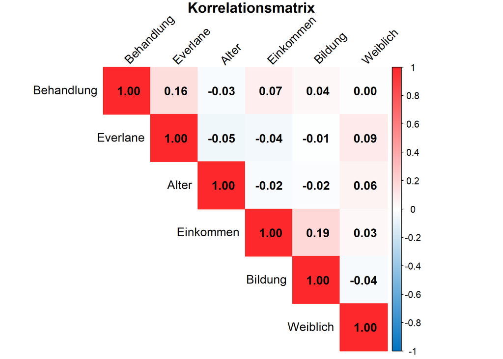

**1. Beschreibung der Matrix**

In dieser Aufgabe wurde eine Korrelationsmatrix für sechs zentrale Variablen aus dem Datensatz daten_exp1 berechnet: age, income, educ, female, treatment (Zugehörigkeit zur Transparenzgruppe) und everlane (Wahl der Everlane-Gutscheinkarte). Die Pearson-Korrelationskoeffizienten wurden berechnet, um lineare Zusammenhänge zwischen den Variablen zu untersuchen. Die Ergebnisse wurden anschließend mithilfe des corrplot-Pakets visualisiert, wobei die Stärke und Richtung der Zusammenhänge farblich dargestellt ist.

Zur Berechnung wurden zuvor alle Beobachtungen mit fehlenden Werten entfernt, um eine valide Analyse durchzuführen. Die Visualisierung zeigt die Werte farblich skaliert von Blau (stark negativ) bis Rot (stark positiv). Die Zahlen in den Kästchen geben zusätzlich die exakten Korrelationskoeffizienten an.

**2. Interpretation der Ergebnisse**

Die Korrelation zwischen treatment und everlane beträgt r = 0.16, was auf einen schwachen positiven Zusammenhang hindeutet: Personen, die die Produktseite mit Kostentransparenz gesehen haben, entschieden sich etwas häufiger für Everlane als solche in der Kontrollgruppe.

Auch zwischen treatment und den Kontrollvariablen (age, income, educ, female) bestehen kaum Korrelationen, was erneut dafür spricht, dass die Randomisierung erfolgreich war.

Insgesamt lässt sich festhalten: Die Grafik liefert eine gute Übersicht, es bestehen keine multikollinearen Muster oder auffälligen Zusammenhänge zwischen den Kontrollvariablen.

**3. Reflexion: Interpretation der Zusammenhänge**

*a) Was bedeutet ein positiver Zusammenhang zwischen treatment und everlane im Kontext der Hypothese?*

Ein positiver Zusammenhang bedeutet, dass Teilnehmende der Treatmentgruppe tendenziell häufiger Everlane gewählt haben. Das stützt die Hypothese, dass Kostentransparenz das Konsumentenverhalten beeinflusst. Dennoch bleibt dieser Zusammenhang relativ schwach (r = 0.16), was darauf hindeutet, dass weitere Faktoren eine Rolle spielen oder dass der Effekt nur moderat ausgeprägt ist.

*b) Warum reicht eine Korrelation nicht für kausale Schlüsse aus – selbst bei randomisierter Treatment-Zuweisung?*

Eine Korrelation beschreibt nur einen statistischen Zusammenhang, aber nicht die Richtung oder Ursache. Auch wenn treatment im Experiment zufällig zugewiesen wurde, können andere Einflüsse (z.B. ungemessene Einstellungen oder Vertrautheit mit Marken) das Verhalten mitprägen. Erst durch kontrollierte Regressionsanalysen, bei denen andere Faktoren konstant gehalten werden, lässt sich ein kausaler Effekt isolieren. Korrelation ist also notwendig, aber nicht hinreichend, um eine Wirkung nachzuweisen.

*c) Was ist der Vorteil einer Korrelationsmatrix gegenüber einem Mittelwertvergleich?*

Ein einfacher Mittelwertvergleich zeigt nur Unterschiede auf einer einzelnen Zielvariablen (z.B. Everlane-Wahl zwischen Gruppen), sagt aber nichts über Wechselwirkungen oder Zusammenhänge zwischen mehreren Variablen aus. Die Korrelationsmatrix dagegen erlaubt es, alle paarweisen linearen Zusammenhänge auf einen Blick zu sehen – auch zwischen potenziellen Kontrollvariablen. Dadurch kann man z.B. frühzeitig erkennen, ob Multikollinearität vorliegt oder ob bestimmte Variablen möglicherweise redundante Informationen liefern.

7. In Aufgabe 1 und 2 haben Sie gelesen, dass den Teilnehmern ein Angebot gemacht wurde, eine Everlane-Gutscheinkarte anzunehmen. Erzeugen Sie eine geeignete Grafik, die den durchschnittlichen Anteil der angenommenen Angebote (d.h. den Anteil, in dem die Everlane-Karte gewählt wurde) getrennt für die Treatment- und die Kontrollgruppe darstellt. Fügen Sie in der Grafik zusätzlich den Standardfehler der Mittelwerte ein. Führen Sie einen T-Test durch, um zu prüfen, ob der Unterschied im Mittelwert zwischen der Treatment- und Kontrollgruppe statistisch signifikant ist, und geben Sie das Testergebnis (den p-Wert) deutlich sichtbar in der Grafik an. Achten Sie dabei auf eine verständliche Beschriftung Ihrer Grafik sowie auf einen aussagekräftigen Titel.

Beschreiben und interpretieren Sie ihre Grafik. Gehen Sie insbesondere auf folgende Fragen ein:

- Welche Aussage lässt sich auf Basis des durchgeführten T-Tests treffen?
- Welche der in den vorherigen Aufgaben (vgl. Aufgabe 4 und 5) analysierten Faktoren könnten dazu beigetragen haben, dass ein signifikanter Unterschied im Anteil angenommener Everlane-Angebote zwischen Treatment- und Kontrollgruppe beobachtet wird?

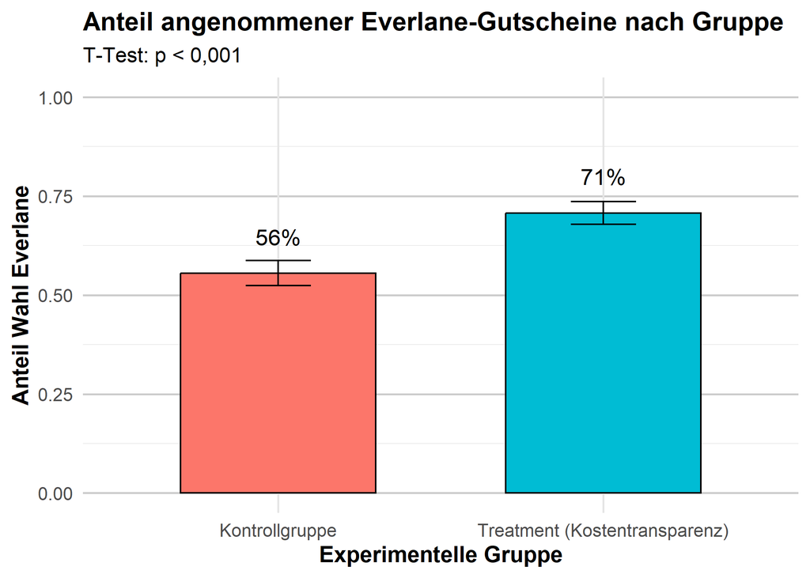

**Einordnung und Beschreibung der Grafik**

Die Balkengrafik veranschaulicht den durchschnittlichen Anteil der Teilnehmer:innen, die sich für die Annahme eines Everlane-Gutscheins entschieden haben. Die Darstellung unterscheidet dabei zwischen einer Kontrollgruppe, die keine zusätzlichen Informationen erhielt, und einer Treatmentgruppe, der im Vorfeld eine transparente Darstellung der Kostenstruktur präsentiert wurde.

Jeder Balken der Grafik zeigt den Mittelwert des jeweiligen Gruppenanteils, während vertikale Linien den mit Standardfehler des Mittelwerts darstellen. Diese Fehlerbalken geben einen Eindruck von der Unsicherheit der Schätzung. Schon auf den ersten Blick wird ersichtlich, dass die Treatmentgruppe eine deutlich höhere Annahmequote des Gutscheins aufweist. Die Balken unterscheiden sich sichtbar, und auch die Fehlerbalken überlappen sich kaum – was darauf hindeutet, dass der Unterschied zwischen den Gruppen nicht zufällig ist.

**Interpretation der beobachteten Unterschiede**

Die Grafik deutet klar darauf hin, dass die Transparenz über die Preisgestaltung bei Everlane das Verhalten der Konsument:innen beeinflusst hat. Teilnehmer:innen, die diese Information erhalten haben, entschieden sich deutlich häufiger für die Annahme des Gutscheins als jene in der Kontrollgruppe. Dieses Verhalten lässt sich als Ausdruck eines gestiegenen Vertrauens in das Unternehmen interpretieren. Transparente Preisgestaltung könnte als Signal für Fairness, Ehrlichkeit und Authentizität wahrgenommen worden sein – Werte, die Konsument:innen in ihrer Entscheidung positiv beeinflussen. Die Grafik vermittelt somit nicht nur einen statistischen Unterschied, sondern auch einen inhaltlich nachvollziehbaren Effekt auf das Konsumentenverhalten.

**Statistische Bewertung durch den T-Test**

Ergänzend zur grafischen Darstellung wurde ein zweiseitiger T-Test durchgeführt, um den Unterschied zwischen den Gruppen statistisch zu prüfen. Der p-Wert des Tests beträgt 0,000043 und liegt damit deutlich unter der gängigen Signifikanzgrenze von 5 Prozent. Das Ergebnis erlaubt eine eindeutige Interpretation: Der Unterschied zwischen den Gruppen ist hochsignifikant. Es besteht eine extrem geringe Wahrscheinlichkeit, dass dieser Unterschied durch Zufall entstanden ist. Die Behandlung – also die Information über die Kostenstruktur – hat somit einen messbaren und signifikanten Einfluss auf die Entscheidung, den Everlane-Gutschein anzunehmen.

**Erklärungsansätze für den beobachteten Unterschied**

Zur Einordnung der Ursachen dieses Effekts wurden in vorherigen Aufgaben demografische Merkmale wie Alter, Geschlecht, Einkommen und Bildungsniveau zwischen den Gruppen verglichen. Diese sogenannte Balancing-Analyse ergab, dass die beiden Gruppen in Bezug auf ihre Zusammensetzung weitgehend vergleichbar sind. Lediglich beim Einkommen zeigte sich ein leichter Unterschied, der jedoch statistisch nicht signifikant war. Dies spricht dafür, dass der beobachtete Unterschied nicht durch strukturelle Verzerrungen, sondern durch das Treatment selbst – also die Transparenzinformation – verursacht wurde.

**Zusammenfassende Bewertung der Ergebnisse**

Die präsentierten Ergebnisse lassen insgesamt den Schluss zu, dass die Transparenzinformation in der Treatmentgruppe einen klaren Effekt auf das Entscheidungsverhalten hatte. Die Teilnehmer:innen dieser Gruppe waren signifikant häufiger bereit, den Everlane-Gutschein anzunehmen. Da sich keine gravierenden Unterschiede in der Zusammensetzung der Gruppen nachweisen lassen und begleitende Vertrauensmerkmale ebenfalls positiv ausfielen, liegt es nahe, den Effekt als Ausdruck eines gesteigerten Vertrauens zu interpretieren.

Diese Erkenntnis ist sowohl theoretisch als auch praktisch bedeutsam: Sie zeigt, dass Maßnahmen zur Erhöhung der Transparenz tatsächlich Verhalten beeinflussen können – und liefert damit einen konkreten Hinweis darauf, wie Unternehmen durch glaubwürdige Kommunikation Vertrauen aufbauen und die Akzeptanz ihrer Angebote erhöhen können.

In den vorherigen Aufgaben des Projekts haben Sie sich bereits intensiv mit dem Experiment 1 auseinandergesetzt, in dem untersucht wurde, ob und wie die Offenlegung von Produktionskosten - also Kostentransparenz - das Konsumverhalten beeinflusst. Es wurde gezeigt: Wenn Konsument:innen transparent mitgeteilt wird, wie sich die Kosten eines Produkts zusammensetzen, steigt ihre Bereitschaft, bei dem entsprechend transparenten Unternehmen einzukaufen.

Diese Ergebnisse legen nahe, dass die Offenlegung sensibler Unternehmensinformationen (wie Produktionskosten) das Vertrauen der Konsument:innen in das Unternehmen stärkt und sie somit eher zu einem Kauf motiviert.

Doch was genau ist der psychologische Mechanismus hinter dieser Wirkung? Ist es tatsächlich das Vertrauen in das Unternehmen, das durch die Offenlegung sensibler Informationen gestärkt wird - und in der Folge die Kaufbereitschaft erhöht?

Um genau diese Frage zu beantworten, führen die Autoren ein weiteres Experiment durch, das den vermuteten psychologischen Vermittlungsmechanismus des Vertrauens genauer untersucht. Dabei wurde geprüft, ob Vertrauen tatsächlich als Mediator zwischen Kostentransparenz und Kaufinteresse wirkt. Hierzu wurde ein kontrolliertes Online-Experiment mit über 600 Teilnehmer:innen durchgeführt. Die Teilnehmenden wurden zufällig einer von zwei Bedingungen zugewiesen:

- In der **Kostentransparenz-Gruppe** (Treatment) wurde zusätzlich eine detaillierte Aufschlüsselung der Produktionskosten angegeben. Diese beinhaltete die einzelnen Kostenkomponenten (z.B. Kakaobutter, Verpackung, Arbeitskosten) sowie die Gesamtkosten der Schokoladentafel (vgl. Abbildung 2 im Anhang).
- In der **Kontrollgruppe** sahen die Teilnehmer die Verpackung einer fiktiven Schokoladenmarke namens „Cocoa Passion“. Diese enthielt nur die üblichen Informationen wie Zutaten, Nährwerte und eine Produktbeschreibung.

Ziel war es, zu untersuchen, ob die Offenlegung dieser sensiblen Informationen das Vertrauen der Konsument:innen in die Marke stärkt - und ob dieses Vertrauen wiederum die Kaufbereitschaft beeinflusst. In den nächsten Aufgaben werden Sie diese Studie genauer beleuchten, analysieren und evaluieren, ob sich die Hypothese empirisch bestätigen lässt.

8. Lesen Sie die Daten des zweiten Experiments (`Experiment2.csv`) in R ein. Nennen Sie den Datensatz `daten_exp2`. Benennen Sie die Variable `cost` in `treatment` um.

Untersuchen Sie, ob sich die Teilnehmer, die die Verpackung mit transparenter Kosteninformation gesehen haben, systematisch von jenen unterscheiden, die nur die Kontrollversion gesehen haben.

Erstellen Sie hierfür eine Balancing-Tabelle, in der Sie die Mittelwerte von Alter (age), Geschlecht (female), Einkommensstufe (income), Bildungsniveau (educ), Vertrauen (trust) und Kaufbereitschaft (wtb) zwischen den beiden Gruppen vergleichen, die Differenzen berechnen und mithilfe von T-Tests prüfen, ob diese Unterschiede statistisch signifikant sind. Nehmen Sie weiterhin die Anzahl an Beobachtungen in der Treatment- und in der Kontrollgruppe in ihre Tabelle mit auf.

Beschreiben und interpretieren Sie ihre Tabelle. Gehen Sie dabei insbesondere auf folgende Fragen ein:

- Was versteht man unter der Variable `wtb`?
- Was lässt sich aus der Größen der Stichprobe ableiten?
- Wo könnte es bei einer Regression (oder einem sonstigen Vergleich der Gruppen) zu Problemen kommen und was wären mögliche Auswirkungen?

*Hinweis:* Für die Beschreibung der `wtb` können Sie das bereitgestellte Readme nutzen.

Balancing-Tabelle für Experiment 2

| Variable | Mittelwert.Kontrolle | Mittelwert.Treatment | Differenz | p.Wert |
| --- | --- | --- | --- | --- |
| Alter | 36.27 | 34.06 | -2.21 | 0.0160 |
| Weiblich (Anteil) | 0.42 | 0.48 | 0.05 | 0.2066 |
| Einkommen (1–12) | 6.96 | 6.79 | -0.17 | 0.3720 |
| Bildung (1–5) | 3.51 | 3.57 | 0.05 | 0.4430 |
| Vertrauen (1–7) | 4.82 | 5.27 | 0.45 | 0.0001 |
| Kaufbereitschaft (1–7) | 3.74 | 4.27 | 0.53 | 0.0012 |

Hinweis: Stichprobengröße: Treatment = 306, Kontrolle = 308

**Ziel der Analyse und Aufbau der Aufgabe**

Im Rahmen des zweiten Experiments wurde untersucht, ob eine transparente Kommunikation der Produktionskosten auf der Verpackung eines Produkts Einfluss auf das Vertrauen und die Kaufbereitschaft von Konsument:innen nimmt. Um sicherzustellen, dass ein solcher Effekt tatsächlich durch das Treatment (also die Transparenzmaßnahme) verursacht wurde, ist es notwendig zu prüfen, ob sich die Gruppen im Experiment – die Treatmentgruppe und die Kontrollgruppe – in ihrer Zusammensetzung grundsätzlich unterscheiden. Diese Überprüfung erfolgt mit Hilfe einer sogenannten Balancing-Tabelle.

Ziel dieser Analyse ist es daher, mögliche systematische Unterschiede zwischen den beiden Gruppen zu identifizieren. Dabei werden zentrale demografische Merkmale (Alter, Geschlecht, Einkommen und Bildung) sowie psychologische Zielgrößen (Vertrauen in das Unternehmen und Kaufbereitschaft) auf Unterschiede in Mittelwerten überprüft. Zusätzlich wird mittels zweiseitiger T-Tests getestet, ob diese Unterschiede statistisch signifikant sind. Eine ausreichende Vergleichbarkeit beider Gruppen ist die Voraussetzung dafür, dass in nachfolgenden Regressionsmodellen oder Kausalanalysen keine Verzerrungen entstehen.

**Beschreibung der Variablen und der Stichprobe**

Die zugrundeliegenden Daten stammen aus dem Datensatz Experiment2.csv, in dem die Variable cost – die angibt, ob eine Person die transparente Verpackung gesehen hat oder nicht – in treatment umbenannt wurde. Die Balancing-Tabelle umfasst insgesamt sechs Variablen:

Die Variable age gibt das Alter der Teilnehmer:innen an und wurde offen erfasst. female ist eine binäre Variable, die den Wert 1 annimmt, wenn eine Teilnehmerin weiblich ist, und den Wert 0 bei männlichen Teilnehmern. Das Einkommen wurde auf einer ordinalen Skala mit zwölf Stufen erfasst, wobei Stufe 1 „kein Einkommen“ und Stufe 12 „weiß nicht/bevorzuge keine Angabe“ entspricht. Auch das Bildungsniveau wurde als ordinale Variable auf einer Skala von 1 bis 5 gemessen – von „einige Jahre Schule“ bis „postgradual/beruflich“.

Besonders wichtig für dieses Experiment sind jedoch die beiden psychologischen Variablen trust und wtb. Die Variable trust erfasst auf einer Skala von 1 bis 7, wie vertrauenswürdig das Unternehmen eingeschätzt wird – wobei 1 „überhaupt nicht vertrauenswürdig“ und 7 „sehr vertrauenswürdig“ bedeutet. Die Variable wtb steht für „willingness to buy“, also die Kaufbereitschaft der Teilnehmer:innen. Auch sie wurde auf einer Skala von 1 (überhaupt nicht wahrscheinlich) bis 7 (sehr wahrscheinlich) erfasst. Diese Variable ist besonders relevant, da sie das tatsächliche Konsumverhalten approximiert und somit direkt an das Ziel des Experiments anknüpft.

Die Stichprobengröße ist in beiden Gruppen nahezu identisch: In der Treatmentgruppe befinden sich 306 Beobachtungen, in der Kontrollgruppe 308. Diese Gleichverteilung spricht für eine erfolgreiche Randomisierung und schafft eine solide Basis für alle weiteren statistischen Auswertungen.

**Ergebnisse der Balancing-Tabelle**

Die Auswertung der Balancing-Tabelle zeigt, dass sich die beiden Gruppen in den meisten demografischen Merkmalen nur geringfügig unterscheiden. Ein signifikanter Unterschied konnte lediglich im Alter festgestellt werden: Die Teilnehmer:innen in der Treatmentgruppe sind im Durchschnitt etwa zwei Jahre jünger als jene in der Kontrollgruppe. Dieser Unterschied ist mit einem p-Wert von 0,016 statistisch signifikant. Zwar ist der Unterschied in absoluten Zahlen eher klein, dennoch sollte er in nachfolgenden Modellen als Kontrollvariable berücksichtigt werden.

Für die Variable Geschlecht – gemessen am Anteil weiblicher Teilnehmer:innen – wurde kein signifikanter Unterschied festgestellt. Auch in Bezug auf Einkommen und Bildung sind die Gruppen sehr ähnlich. Die T-Tests liefern hier p-Werte, die deutlich über dem Schwellenwert von 0,05 liegen, sodass man davon ausgehen kann, dass keine substantiellen Unterschiede in diesen Merkmalen vorliegen. Diese Ergebnisse lassen darauf schließen, dass die Randomisierung im Experiment grundsätzlich gelungen ist.

Deutlichere Unterschiede ergeben sich dagegen bei den beiden psychologischen Variablen. Das Vertrauen in das Unternehmen (trust) ist in der Treatmentgruppe signifikant höher als in der Kontrollgruppe. Der Mittelwert liegt klar über dem der Kontrollgruppe, und der zugehörige p-Wert ist mit < 0,001 hochsignifikant. Dies deutet darauf hin, dass die transparente Darstellung der Produktionskosten tatsächlich das Vertrauen in das Unternehmen gesteigert hat.

Ein ähnliches Muster zeigt sich bei der Kaufbereitschaft (wtb). Auch hier weist die Treatmentgruppe einen höheren Mittelwert auf. Der p-Wert des Gruppenunterschieds beträgt rund 0,0012 und ist somit ebenfalls statistisch signifikant. Die Tatsache, dass sowohl das Vertrauen als auch die Kaufbereitschaft in der Treatmentgruppe signifikant höher ausfallen, spricht für die Effektivität der Maßnahme – also der Kostenoffenlegung auf der Verpackung.

**Bedeutung und Interpretation der Variable wtb**

Die Variable wtb („willingness to buy“) ist eine der zentralen Zielvariablen dieses Experiments. Sie misst die subjektive Einschätzung der Teilnehmer:innen, ob sie das betrachtete Produkt – in diesem Fall eine Schokolade – kaufen würden. Diese Einschätzung wurde mithilfe einer siebenstufigen Skala erhoben. Die Interpretation dieser Skala reicht von 1 („überhaupt nicht wahrscheinlich“) bis 7 („sehr wahrscheinlich“).

Da es sich bei der Kaufbereitschaft um ein zentral psychologisches Maß für Konsumverhalten handelt, ist wtb ein direkter Indikator dafür, wie erfolgreich eine Maßnahme zur Vertrauenssteigerung – wie etwa Kostentransparenz – auf die tatsächliche Handlungsabsicht wirkt. Der signifikante Unterschied in dieser Variable zwischen den Gruppen zeigt somit nicht nur einen statistischen, sondern auch einen praktisch relevanten Effekt der Transparenzintervention.

**Ableitungen aus der Stichprobengröße**

Mit über 300 Teilnehmer:innen in jeder Gruppe verfügt das Experiment über eine solide Stichprobengröße. Dies ist nicht nur aus Sicht der statistischen Power vorteilhaft – also der Fähigkeit, auch kleinere Effekte nachweisen zu können –, sondern sorgt auch für eine größere Robustheit gegenüber zufälligen Schwankungen in den Daten.

Die Tatsache, dass die Gruppen zudem nahezu gleich groß sind, spricht für eine gelungene Randomisierung und reduziert die Gefahr von strukturellen Verzerrungen. Insbesondere bei psychologischen Variablen wie Vertrauen oder Kaufbereitschaft, die subjektiven Einschätzungen unterliegen, ist eine hohe Beobachtungszahl ein klarer methodischer Vorteil.

**Potenzielle Probleme bei Regressionsmodellen**

Trotz der weitgehenden Balance der Gruppen können in nachgelagerten Regressionsanalysen theoretisch Probleme auftreten. Eine erste mögliche Quelle für Verzerrungen ist Multikollinearität, also die hohe Korrelation zwischen unabhängigen Variablen. Sollte beispielsweise das Bildungsniveau stark mit dem Einkommen zusammenhängen, könnte dies zu instabilen Schätzungen der Regressionskoeffizienten führen.

Ein weiteres Problem könnte Heteroskedastizität sein, also eine ungleiche Streuung der Fehlerterme zwischen den Gruppen. Dies würde insbesondere die Standardfehler der Schätzungen verzerren, was zu fehlerhaften Signifikanztests führen könnte. In einem solchen Fall wäre der Einsatz robuster Standardfehler eine geeignete Gegenmaßnahme.

Darüber hinaus könnten nicht beobachtbare Drittvariablen eine Rolle spielen, die mit dem Treatment oder der Zielgröße in Zusammenhang stehen. Beispielsweise könnte es sein, dass Personen mit einer höheren Affinität zu nachhaltigen Produkten empfänglicher für Transparenzinformationen sind – und diese Affinität wurde im Experiment möglicherweise nicht direkt erhoben.

Trotz dieser theoretisch denkbaren Einschränkungen bietet die vorliegende Balancing-Tabelle eine gute Grundlage dafür, dass das Treatment isoliert betrachtet werden kann. Die Gruppen weisen im Wesentlichen ähnliche demografische Merkmale auf, sodass Unterschiede in Vertrauen und Kaufbereitschaft plausibel dem Effekt der transparenten Verpackung zugeschrieben werden können.

**Fazit**

Insgesamt zeigt die Balancing-Tabelle, dass die Gruppen des zweiten Experiments in ihren demografischen Merkmalen weitgehend vergleichbar sind. Der einzige signifikante Unterschied liegt im Alter, dessen Einfluss jedoch durch Kontrollvariablen in Regressionsmodellen leicht berücksichtigt werden kann. Die psychologischen Zielgrößen – Vertrauen in das Unternehmen und Kaufbereitschaft – unterscheiden sich dagegen deutlich zugunsten der Treatmentgruppe. Dies spricht dafür, dass die Transparenzmaßnahme auf der Verpackung einen positiven Effekt auf die Wahrnehmung des Produkts sowie auf die Handlungsabsicht der Konsument:innen hat.

9. In ihrem Datensatz gibt es einige Beobachtungen ohne vorhandene Werte. Behalten Sie nur die Beobachtungen bei denen vollständige Werte vorliegen. Erzeugen Sie eine geeignete Grafik, welche den durchschnittlichen Anteil der ‘Kaufbereitschaft’ im zweiten Experiment für die Treatment- und Kontrollgruppe darstellt.

Die Grafik soll:

- die Mittelwerte der Kaufbereitschaft für beide Gruppen zeigen,
- die zugehörigen Standardfehler als Fehlerbalken visualisieren und
- das Ergebnis des T-Tests, der die Mittelwertdifferenz prüft, direkt in die Grafik integrieren.

Beschreiben und interpretieren Sie ihre Grafik.

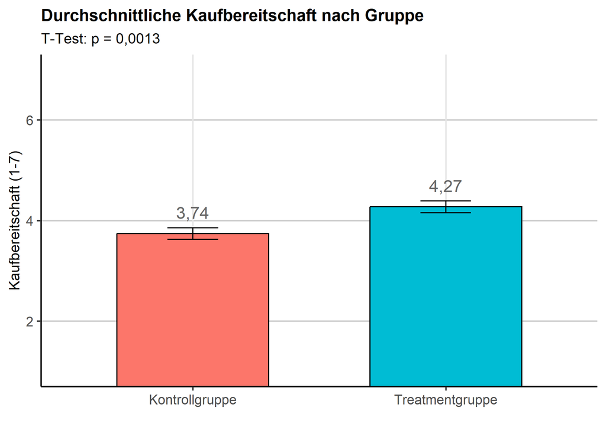

**Beschreibung**

**Interpretation der Beobachtungen**

*1. Höhere Kaufbereitschaft in der Treatmentgruppe*

Die Treatmentgruppe weist mit etwa 4,27 eine deutlich höhere durchschnittliche Kaufbereitschaft auf als die Kontrollgruppe mit 3,74. Diese Differenz von 0,53 Punkten stützt die Hypothese, dass die Offenlegung von Produktionskosten das Kaufinteresse von Konsumenten positiv beeinflusst.

*2. Fehlerbalken (Standardfehler)*

Die dargestellten Standardfehler überlappen sich kaum, was visuell darauf hinweist, dass der beobachtete Unterschied nicht allein auf zufällige Schwankungen zurückzuführen ist. Dies spricht für einen systematischen Effekt, der jedoch statistisch überprüft werden muss.

*3.Signifikanter Unterschied laut T-Test*

Die Signifikanz der Mittelwertdifferenz wurde mithilfe eines klassischen Zwei-Stichproben-T-Tests geprüft. Der resultierende p-Wert von 0,0013 liegt deutlich unter dem üblichen Schwellenwert von 0,05. Somit ist der Unterschied statistisch signifikant. Die Hypothese, dass Kostentransparenz zu erhöhter Kaufbereitschaft führt, wird dadurch empirisch gestützt.

**Einordnung aus konsumpsychologischer Perspektive**

Die Wirkung der Kostentransparenz lässt sich theoretisch durch den Aufbau von Vertrauen erklären. Mohan et al. (2020) argumentieren, dass Konsumenten Unternehmen als glaubwürdiger und fairer wahrnehmen, wenn diese bereit sind, sensible Informationen wie Produktionskosten offenzulegen. Die dadurch gewonnene Transparenz kann das Vertrauen stärken, was wiederum die Kaufbereitschaft erhöht.

Im Rahmen von Experiment 2 wurde dieser Mechanismus untersucht, indem neben der Kaufbereitschaft auch das Vertrauen als potenzieller psychologischer Mediator erfasst wurde. Die höhere Kaufbereitschaft in der Treatmentgruppe lässt sich daher nicht nur als direkter Effekt der Information werten, sondern könnte auch indirekt über Vertrauen als vermittelnde Variable zustande gekommen sein.

**Fazit**

Die Ergebnisse zeigen, dass die Offenlegung von Produktionskosten das Kaufverhalten von Konsumenten messbar beeinflussen kann. Die signifikant höhere Kaufbereitschaft in der Treatmentgruppe belegt, dass Kostentransparenz ein wirkungsvolles Mittel zur Förderung von Vertrauen und zur Steigerung der Kaufneigung ist.

Damit unterstreicht das Ergebnis die Relevanz theoretischer Annahmen zur psychologischen Wirkung von Unternehmenskommunikation. Unternehmen, die sich für mehr Transparenz entscheiden, verbessern nicht nur ihr Image, sondern können auch das tatsächliche Kaufverhalten ihrer Kunden positiv beeinflussen. Vertrauensbildende Maßnahmen wie Kostentransparenz erweisen sich somit als strategisch und ökonomisch sinnvoll.

Nachdem Sie nun die Differenzen in der Kaufabsicht zwischen der Treatment- und der Kontrollgruppe im zweiten Experiment überprüft und getestet haben, geht es im nächsten Schritt darum, den möglichen Mediator Vertrauen genauer zu untersuchen. Hierfür sollen Sie sich in einem ersten Schritt das Vertrauen der Personen allgemein anschauen, um einen Eindruck zu dieser wichtigen Variable zu bekommen. Dafür werden Personen anhand **hohem und niedrigem** Vertrauen und deren Kaufbereitschaft für das Produkt unterteilt.

10. Erstellen Sie eine oder mehrere geeignete Grafik(en), die den Zusammenhang zwischen Vertrauen (Trust) und der Kaufabsicht (WTB) **unabhängig** der beiden Treatment- und Kontrollgruppen darstellen. Achten Sie auf eine passende Darstellung der Informationen.

Die Grafik(en) sollen folgende Informationen enthalten:

- Unterteilen Sie ihre Daten in Personen mit `hohem` und `niedrigem` Vertrauen. Nutzen Sie für die Unterteilung den Median des Vertrauens in ihren Daten als Schwellenwert.
- Abhängig der Einstufungen in `hohes` und `niedriges` Vertrauen soll nun die durchschnittliche Kaufbereitschaft dargestellt werden. Hier soll die Grafik so dargestellt werden, dass auf der x-Achse das Vertrauensniveau (“hoch” und “niedrig”) und auf der y-Achse die entsprechende Kaufbereitschaft abgebildet wird.
- Berechnen Sie weiterhin die Mittelwerte der beiden Vertrauensgruppen und visualisieren diese in geeigneter Art und Weise in ihren Grafik(en).
- Führen Sie einen t-Test durch, um zu prüfen, ob die Mittelwertsunterschiede zwischen den beiden Vertrauensgruppen statistisch signifikant sind. Geben Sie den p-Wert in der Grafik an.

Beschreiben und interpretieren Sie ihre Grafik(en). Beantworten Sie insbesondere folgende Fragen:

- Welche Implikationen hat ein signifikanter Unterschied für die Rolle von Vertrauen auf Kaufentscheidungen?
- Wie stark unterscheidet sich die Kaufbereitschaft zwischen Personen mit hohem und niedrigem Vertrauen?
- Könnte auf Basis ihrer Darstellung Vertrauen als Mediator zwischen dem Treatment und der Kaufbereitschaft fungieren?

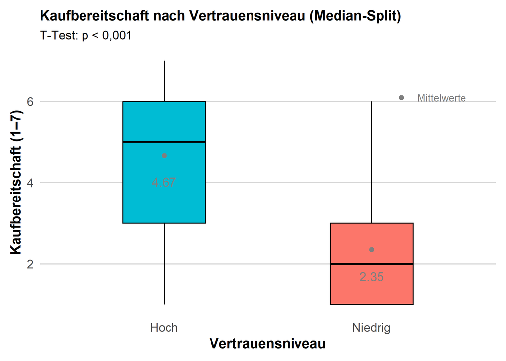

**Analyse des Zusammenhangs zwischen Vertrauen und Kaufbereitschaft**

Die nachfolgende Grafik untersucht, ob das Vertrauen der Konsumenten in das Unternehmen – unabhängig von der Experimentbedingung – einen Einfluss auf ihre Kaufbereitschaft ausübt. Grundlage hierfür ist die Variable trust, die das Vertrauen auf einer Skala von 1 (sehr gering) bis 7 (sehr hoch) misst. Anhand des Medians dieser Variable wurde die Stichprobe in zwei Gruppen unterteilt: Personen mit niedrigem Vertrauen (trust ≤ Median) und solche mit hohem Vertrauen (trust > Median). Erstere sind in Rot, letztere in Türkis dargestellt.

Für beide Gruppen wurde die Verteilung der Kaufbereitschaft (wtb) in einem Boxplot dargestellt. Zusätzlich sind die Mittelwerte der jeweiligen Gruppen als Punkte eingezeichnet und in der Grafik numerisch angegeben. Zur Prüfung der Mittelwertdifferenz wurde ein Zwei-Stichproben-T-Test durchgeführt, dessen p-Wert direkt in der Grafik angegeben ist.

**Ergebnisse und Interpretation**

Die Darstellung zeigt einen deutlichen Unterschied in der Kaufbereitschaft zwischen den beiden Vertrauensgruppen. Teilnehmende mit niedrigem Vertrauen weisen im Durchschnitt eine Kaufbereitschaft von etwa 2.35 auf, während dieser Wert bei Personen mit hohem Vertrauen bei rund 4.67 liegt. Der Unterschied beträgt somit etwa 2.3 Punkte auf einer Skala von 1 bis 7 – ein Effekt, der auch praktisch bedeutsam ist und nicht nur statistisch signifikant.

Der T-Test bestätigt dies eindeutig: Der ermittelte p-Wert liegt deutlich unter dem 1%-Niveau (p < 0,001) und unterstreicht die hohe Signifikanz des Zusammenhangs.

**Implikationen für das Konsumentenverhalten**

Die Ergebnisse unterstreichen die zentrale Rolle des Vertrauens im Konsumverhalten. Vertrauen reduziert subjektiv empfundene Unsicherheit, stärkt die wahrgenommene Glaubwürdigkeit und Fairness eines Unternehmens und fördert dadurch die Kaufneigung. Konsumenten mit höherem Vertrauen sind demnach deutlich eher bereit, Produkte zu erwerben – selbst bei identischen Produktinformationen.

**Vertrauen als potenzieller Mediator**

Die Analyse liefert zudem erste Hinweise darauf, dass Vertrauen als vermittelnder Mechanismus (Mediator) zwischen der Offenlegung von Produktionskosten (Treatment) und der Kaufbereitschaft wirken könnte. In einer vorangegangenen Analyse wurde bereits gezeigt, dass Kostentransparenz das Vertrauen signifikant erhöht. In Kombination mit dem nun nachgewiesenen starken Einfluss von Vertrauen auf die Kaufabsicht ergibt sich ein plausibler mediierter Zusammenhang:

Kostentransparenz → Vertrauen → Kaufbereitschaft

Die in Aufgabe 9 beobachtete Wirkung der Treatmentbedingung könnte demnach zumindest teilweise über das Vertrauen vermittelt sein. Dieser Mediationspfad wird im weiteren Verlauf der Analyse noch genauer empirisch geprüft.

**Fazit**

Die vorliegende Analyse zeigt, dass Vertrauen einen starken und signifikanten Einfluss auf die Kaufbereitschaft hat. Der beobachtete Unterschied zwischen den Vertrauensgruppen ist sowohl statistisch signifikant als auch ökonomisch relevant. Diese Ergebnisse stützen die Hypothese, dass Vertrauen ein entscheidender Treiber von Konsumentscheidungen ist.

Darüber hinaus liefern die Befunde belastbare Hinweise darauf, dass Vertrauen auch eine vermittelnde Rolle zwischen Marketingmaßnahmen (z.B. Kostentransparenz) und Kaufverhalten spielen könnte. Für Unternehmen ergibt sich daraus die strategische Implikation, dass gezielte Maßnahmen zur Vertrauensbildung – etwa durch transparente Kommunikation – eine wirkungsvolle Möglichkeit darstellen, die Kaufbereitschaft der Kund:innen messbar zu steigern.

# Regressionsanalyse

Sie haben nun ihren Datensatz kennengelernt und es scheint so, als ob insbesondere Personen, welche transparente Kosten sehen, dazu neigen, das Produkt zu kaufen. Doch um ihre deskriptiven Analysen zu erhärten, wollen Sie im folgenden eine Analyse mittels Regressionen durchführen.

11. Betrachten Sie hier noch einmal das erste Experiment (`daten_exp1`). Führen Sie eine Regression durch, bei der Ihnen `everlane` als abhängige Variable dient. Als erklärende Variable nutzen Sie das `treatment`. Erstellen sie eine weitere Regression, die zusätzlich noch für die folgenden Variablen kontrolliert:
- Alter
- Bildungsstufe
- Einkommen
- Geschlecht

Stellen Sie die Regressionsergebnisse in einer Tabelle mit stargazer oder modelsummary dar!

Beschreiben und interpretieren Sie ihre Ergebnisse. Gehen Sie insbesondere auf folgende Fragen ein:

- Lässt sich der Effekt des Treatments auf die Entscheidung der Kunden kausal interpretieren?
- Ist es wichtig auf weitere Faktoren zu kontrollieren?
- Beziehen Sie sich hier auch auf die Ergebnisse aus Aufgabe 5.

|  | Ohne Kontrolle | Mit Kontrolle |
| --- | --- | --- |
| Treatment (Kostentransparenz) | 0.66*** | 0.68*** |
|  | (0.19) | (0.19) |
| Alter |  | -0.01 |
|  |  | (0.01) |
| Bildung |  | -0.00 |
|  |  | (0.11) |
| Einkommen |  | -0.05 |
|  |  | (0.04) |
| Weiblich |  | 0.41* |
|  |  | (0.19) |
| Num.Obs. | 505 | 505 |
| R2 | 0.019 | 0.030 |
| R2 Adj. | 0.016 | 0.015 |
| AIC | 656.0 | 656.5 |
| BIC | 664.5 | 681.9 |
| RMSE | 0.48 | 0.47 |
| Std.Errors | IID | IID |

+ p < 0.1, * p < 0.05, ** p < 0.01, *** p < 0.001

**Beschreibung und Interpretation der Regressionsanalyse**

Die obige Tabelle zeigt die Ergebnisse zweier logistischer Regressionsmodelle. In beiden Modellen ist die abhängige Variable everlane, also die binäre Entscheidung der Teilnehmenden, die Marke Everlane zu wählen (1 = gewählt, 0 = nicht gewählt). Die zentrale erklärende Variable ist treatment, ein Indikator dafür, ob eine Person in der Gruppe mit transparenter Kosteninformation war.

**Modell 1 – Ohne Kontrollvariablen**

Im ersten Modell wird ausschließlich der Einfluss des Treatments auf die Wahrscheinlichkeit, Everlane zu wählen, geschätzt. Der geschätzte Koeffizient für das Treatment beträgt 0,66 und ist auf dem 1%-Niveau signifikant. Dies deutet darauf hin, dass Teilnehmer in der Treatment-Gruppe mit höherer Wahrscheinlichkeit Everlane gewählt haben als solche in der Kontrollgruppe.

**Modell 2 – Mit Kontrollvariablen**

Das zweite Modell berücksichtigt zusätzlich demografische Merkmale wie Alter, Bildung, Einkommen und Geschlecht. Der Effekt des Treatments bleibt mit 0,68 nahezu unverändert und weiterhin hoch signifikant. Dies spricht für eine stabile Schätzung des Haupteffekts und unterstützt die Annahme, dass die Randomisierung erfolgreich war.

**Interpretation der Koeffizienten**

Da es sich um logistische Regressionen handelt, geben die geschätzten Koeffizienten die Effekte auf die logarithmierten Wahrscheinlichkeitsverhältnisse („log-Odds“) an. Diese können exponentiell transformiert werden, um Odds Ratios zu erhalten.

Für das Treatment ergibt sich daraus: 1.93 und 1.97. Das bedeutet: Personen in der Treatment-Gruppe haben etwa 1,93- bis 1,97-mal höhere Chancen, Everlane zu wählen, verglichen mit Personen in der Kontrollgruppe.

**Kausalität: Lässt sich der Treatment-Effekt kausal interpretieren?**

Grundsätzlich gilt: Ein kausaler Effekt ist nur dann interpretierbar, wenn keine systematische Verzerrung durch unbeobachtete Störfaktoren vorliegt. In randomisierten Experimenten ist dies – bei erfolgreicher Randomisierung – gewährleistet. In Aufgabe 5 wurde gezeigt, dass sich Treatment- und Kontrollgruppe hinsichtlich Alter, Bildung und Geschlecht nicht signifikant unterscheiden, was auf eine erfolgreiche Randomisierung hindeutet.

Auch die Tatsache, dass der Treatment-Koeffizient beim Übergang vom einfachen zum erweiterten Modell nahezu konstant bleibt, spricht dafür, dass keine wesentlichen Confounder übersehen wurden. Daher kann der Effekt des Treatments auf die Everlane-Wahl mit hoher Wahrscheinlichkeit kausal interpretiert werden.

**Ist es wichtig, auf weitere Faktoren zu kontrollieren?**

Bei perfekter Randomisierung ist eine Kontrolle von Kovariablen theoretisch nicht notwendig. Praktisch ist es jedoch aus Gründen der Robustheitsprüfung und Präzision sinnvoll, relevante Kontrollvariablen in das Modell aufzunehmen.

Ein zusätzlicher Grund ergibt sich aus Aufgabe 5: Dort zeigte sich ein leichter Unterschied im Einkommen zwischen Treatment- und Kontrollgruppe, der auf dem 10%-Niveau signifikant war. Auch wenn dieser Unterschied zufällig entstanden sein kann, ist eine Kontrolle angebracht, um eventuelle Verzerrungen zu vermeiden. Das erweiterte Modell zeigt jedoch, dass Einkommen keinen signifikanten Einfluss hat – was die Robustheit des Haupteffekts nochmals bestätigt.

**Fazit**

Die Regressionsanalyse bestätigt die Ergebnisse aus der deskriptiven Auswertung: Kostentransparenz erhöht signifikant die Wahrscheinlichkeit, dass Konsumenten Everlane wählen. Der Effekt ist stabil und bleibt auch nach Kontrolle relevanter Kovariablen hochsignifikant.

Da es sich um ein randomisiertes Experiment handelt, und weder der Balancing-Check noch die Regression Hinweise auf systematische Verzerrungen liefern, kann der Effekt mit großer Sicherheit kausal interpretiert werden.

Gleichzeitig legt die Analyse aus Aufgabe 10 nahe, dass Vertrauen als Mediator zwischen Treatment und Kaufentscheidung wirken könnte. Transparente Preisgestaltung fördert das Vertrauen – und dieses beeinflusst wiederum die Entscheidung, ein Produkt zu kaufen. Die Wirkung des Treatments könnte also zumindest teilweise indirekt über Vertrauen verlaufen. Dies wird in den folgenden Analysen noch genauer untersucht.

Während die bisherigen Analysen zeigen, dass das Treatment einen Effekt hat, stellt sich nun die Frage, warum das so ist. Nun sollten Sie im weiteren Verlauf durch vertiefende Regressionsanalysen prüfen, ob dies auf das Vertrauen der Kunden zurückzuführen ist. Dazu betrachten Sie noch einmal den Datensatz zu Experiment 2 (`daten_exp2`) und untersuchen, ob das Treatment (Kunden sehen transparente Kostenstruktur) zu einer höheren Kaufabsicht führt, weil sie das Vertrauen der Konsumenten in das Unternehmen stärkt.

12. Schauen Sie sich den Einfluss der Kostentransparenz auf die Kaufabsicht in den folgenden zwei Regressionen genauer an und zeigen Sie ihre Ergebnisse nebeneinander:

**1. Regression:** Abhängige Variable ist die Kaufabsicht; die erklärende Variable ist das Treatment.

**2. Regression:** Wie in der 1. Regression, doch kontrollieren Sie hier zusätzlich auf die Variablen Alter, Einkommensniveau, Bildungsstufe und Geschlecht.

Stellen Sie die Regressionsergebnisse in einer Tabelle mit stargazer oder modelsummary dar!

Beschreiben und interpretieren Sie ihre Ergebnisse allgemein. Gehen Sie weiterhin auch speziell auf folgende Fragen ein:

- Sollten die Kontrollvariablen in ihrer zweiten Regression den Koeffizienten des Treatments ändern? Was würden Sie erwarten und warum? Nutzen Sie hierzu die Ergebnisse aus Aufgabe 8.
  - Vergleichen Sie die Regressionskoeffizienten der Treatment-Variable in der ersten und zweiten Regression. Gibt es hier einen signifikanten Unterschied in der Größe des Effekts?
- Bringt ihnen die Regression Vorteile gegenüber einer reinen Darstellung der Mittelwerte wie in Aufgabe 9?
- Ist der Effekt des Treatments auf die Kaufabsicht ihrer Ansicht nach kausal interpretierbar?
  - Welche Voraussetzungen müssen erfüllt sein, damit man diesen Regressionskoeffizienten als kausalen Effekt interpretieren kann?
  - Überlegen Sie sich, wie sich das Ergebnis verändern würde, wenn zusätzlich Vertrauen (trust) in das Modell aufgenommen wird. Würde sich der Effekt von `treatment` verändern? Warum oder warum nicht?

|  | Nur Treatment | Mit Kontrolle |
| --- | --- | --- |
| Treatment (Kostentransparenz) | 0.532** | 0.501** |
|  | (0.165) | (0.166) |
| Alter |  | -0.013+ |
|  |  | (0.007) |
| Einkommen |  | 0.023 |
|  |  | (0.036) |
| Bildung |  | 0.102 |
|  |  | (0.099) |
| Weiblich |  | -0.001 |
|  |  | (0.168) |
| Num.Obs. | 601 | 601 |
| R2 | 0.017 | 0.025 |
| R2 Adj. | 0.015 | 0.016 |
| AIC | 2553.0 | 2556.4 |
| BIC | 2561.8 | 2582.7 |
| RMSE | 2.02 | 2.01 |
| Std.Errors | IID | IID |

+ p < 0.1, * p < 0.05, ** p < 0.01, *** p < 0.001

**Interpretation der Regressionsanalyse zur Kaufabsicht**

In der vorliegenden Regressionsanalyse wurde untersucht, ob die Offenlegung einer transparenten Kostenstruktur (Treatment) einen signifikanten Einfluss auf die Kaufabsicht von Konsumenten hat. Hierfür wurden zwei lineare Regressionsmodelle geschätzt:

- Modell 1 berücksichtigt ausschließlich die Treatment-Variable als erklärende Variable.
- Modell 2 kontrolliert zusätzlich für Alter, Einkommen, Bildung und Geschlecht.

In beiden Modellen zeigt sich ein positiver und statistisch signifikanter Effekt der Kostentransparenz auf die Kaufabsicht (wtb). Teilnehmer, die die transparente Kostenaufstellung sahen, bewerteten ihre Kaufabsicht im Durchschnitt höher als jene in der Kontrollgruppe. Die Effektstärke bleibt mit Regressionskoeffizienten von 0,53 (Modell 1) und 0,50 (Modell 2) weitgehend stabil und ist jeweils auf dem 5%-Niveau signifikant. Diese Ergebnisse stimmen mit den deskriptiven Befunden aus Aufgabe 9 überein, wo eine Mittelwertdifferenz von 0,53 Punkten beobachtet wurde.

**Verändert sich der Treatment-Koeffizient durch Kontrollvariablen?**

Der Einschluss von Kontrollvariablen kann die Schätzung des Treatment-Effekts verändern – insbesondere dann, wenn zwischen Treatment- und Kontrollgruppe Unterschiede in den beobachteten Merkmalen bestehen. In einem gut randomisierten Experiment ist jedoch keine substanzielle Veränderung zu erwarten.

Die Balancing-Tabelle aus Aufgabe 8 zeigt, dass sich die Gruppen nicht systematisch in Alter, Einkommen, Bildung und Geschlecht unterscheiden. Der Vergleich der Regressionskoeffizienten bestätigt dies: Der Treatment-Effekt sinkt nur minimal von 0,532 auf 0,501. Diese Stabilität spricht für eine erfolgreiche Randomisierung und unterstützt die Annahme eines robusten kausalen Effekts.

**Vorteile der Regression gegenüber dem Mittelwertvergleich (Aufgabe 9)**

Im Vergleich zur deskriptiven Mittelwertanalyse bietet die Regressionsanalyse mehrere Vorteile:

Kontrolle potenzieller Störfaktoren: Die Regression erlaubt es, Kovariaten zu berücksichtigen, die potenziell mit der abhängigen Variable und dem Treatment zusammenhängen könnten.

Größere Präzision: Die Regression nutzt zusätzlich die Streuung und Kovarianzen der Variablen und liefert daher präzisere Schätzer.

Flexibilität: Regressionsmodelle sind erweiterbar, z.B. für Interaktionen oder Mediationsanalysen.

Die Ergebnisse aus Modell 1 entsprechen dem Mittelwertvergleich aus Aufgabe 9. Modell 2 zeigt, dass der Effekt des Treatments auch unter Kontrolle soziodemografischer Variablen bestehen bleibt – ein wichtiger Hinweis auf Robustheit und kausale Interpretierbarkeit.

**Kann der Effekt kausal interpretiert werden?**

Ja, der Effekt kann mit hoher Wahrscheinlichkeit kausal interpretiert werden, sofern die folgenden Voraussetzungen erfüllt sind:

- Erfolgreiche Randomisierung: Die Balancing-Analyse aus Aufgabe 8 zeigt, dass keine systematischen Unterschiede zwischen den Gruppen bestehen.
- Keine systematische Selektion oder Verzerrung: Da es sich um ein kurzes Laborexperiment ohne Dropouts handelt und unvollständige Beobachtungen vorab entfernt wurden, ist keine relevante Verzerrung zu erwarten.
- Keine Messfehler oder externe Einflüsse: Die Erhebung erfolgte standardisiert, und experimentelle Störeffekte wie Hawthorne, John Henry oder Spillover sind aufgrund des Designs unwahrscheinlich.
- Der Regressionskoeffizient für das Treatment bleibt auch unter Kontrolle anderer Variablen stabil. Diese Beobachtung spricht für eine hohe interne Validität, sodass der Effekt plausibel als kausal interpretiert werden kann.

**Was passiert, wenn trust in das Modell aufgenommen wird?**

Wird die Variable trust zusätzlich in das Modell integriert, ist ein Rückgang des Treatment-Koeffizienten zu erwarten – entweder in der Effektstärke oder der Signifikanz. Der Grund: Vertrauen wird als psychologischer Mechanismus betrachtet, über den Kostentransparenz ihre Wirkung auf die Kaufabsicht entfaltet. In diesem Fall fungiert trust als Mediator.

Wenn Vertrauen also den kausalen Pfad zwischen Treatment und Kaufabsicht vermittelt, absorbiert es einen Teil des ursprünglichen Effekts. Der verbleibende direkte Effekt des Treatments würde entsprechend geringer ausfallen. Ein deutlicher Rückgang des Treatment-Koeffizienten nach Aufnahme von trust wäre ein starker Hinweis auf die vermittelnde Rolle von Vertrauen.

**Fazit**

Die Analyse zeigt, dass Kostentransparenz einen signifikanten, robusten und kausal interpretierbaren Effekt auf die Kaufabsicht hat. Der Effekt bleibt auch unter Kontrolle relevanter Kovariablen bestehen, was für eine gelungene Randomisierung und hohe interne Validität spricht.

Gleichzeitig deuten theoretische Überlegungen sowie die bisherigen empirischen Ergebnisse darauf hin, dass Vertrauen als vermittelnder Mechanismus eine zentrale Rolle spielt. Die Ergebnisse legen somit nahe, dass der beobachtete Effekt indirekt über Vertrauen wirkt – ein Aspekt, der in nachfolgenden Aufgaben empirisch überprüft werden sollte.

Sie haben nun gesehen, dass es auch hier einen direkten Effekt des Treatments (transparente Kostenstrukur) auf die Kaufabsicht gibt. Doch um die dahinter liegenden Mechanismen zu verstehen, müssen Sie tiefer in psychologische Prozesse eintauchen. Experiment 2 zeigt dafür ein entsprechendes Design, um zu testen, ob Vertrauen als vermittelnder Mechanismus eine Rolle spielt. Im nächsten Schritt analysieren Sie nun selbst diese Beziehung mit theoretischen Modellen und Regressionsmethoden, um ein Gefühl dafür zu bekommen, wie sich direkte und indirekte Effekte voneinander unterscheiden.

13. Bevor Sie im nächsten Schritt ein konkretes DAG zu einem psychologischen Mediationsmechanismus erstellen, machen Sie sich zunächst mit den theoretischen Grundlagen von Directed Acyclic Graphs (DAGs) vertraut. DAGs (gerichtete azyklische Graphen) sind ein nützliches Werkzeug in der Kausalanalyse.

Beantworten Sie folgende theoretische Fragen zu DAGs:

- Wofür werden DAGs in der empirischen Forschung verwendet?
- Nennen und beschreiben Sie zwei zentrale Knotentypen in einem DAG: Confounder und Mediator.
- Worin besteht der zentrale Unterschied, ob Vertrauen als Kontrollvariable (Confounder) oder als Mediator behandelt wird - und warum ist Letzteres entscheidend für das Verständnis psychologischer Prozesse im vorliegenden Experiment?

**Wofür werden DAGs in der empirischen Forschung verwendet?**

Directed Acyclic Graphs (DAGs) sind ein wichtiges Werkzeug in der empirischen Forschung, insbesondere im Bereich der Kausalanalyse. Sie dienen der Visualisierung und Strukturierung kausaler Zusammenhänge zwischen Variablen. Ein DAG besteht aus Knoten (die die Variablen repräsentieren) und gerichteten Kanten (Pfeilen), die kausale Wirkungsrichtungen anzeigen. Zyklische Verbindungen sind ausgeschlossen – eine Variable darf also nicht kausal auf sich selbst zurückwirken.

In experimentellen und quasiexperimentellen Studien helfen DAGs dabei, kausale Hypothesen explizit zu formulieren, relevante Störvariablen (Confounder) zu identifizieren und gezielt zu entscheiden, welche Variablen kontrolliert werden müssen, um eine unverzerrte Schätzung kausaler Effekte zu ermöglichen. Sie sind besonders hilfreich, um komplexe Annahmen über den Daten-generierenden Prozess transparent und nachvollziehbar zu machen.

**Zentrale Knotentypen: Confounder und Mediator**

Zwei zentrale Konzepte in DAGs sind Confounder und Mediator – beide spielen eine entscheidende Rolle bei der Interpretation kausaler Zusammenhänge, unterscheiden sich jedoch in ihrer Funktion:

Confounder (Störgröße) ist eine Variable, die kausal sowohl auf das Treatment als auch auf den Outcome (z. B. Kaufabsicht) wirkt. Ein solcher Zusammenhang kann zu einer Verzerrung des geschätzten Effekts führen, wenn nicht dafür kontrolliert wird. In einer nicht-randomisierten Studie könnte zum Beispiel das Einkommen ein Confounder sein, wenn es sowohl die Wahrscheinlichkeit beeinflusst, das Treatment zu erhalten (z. B. bevorzugte Zielgruppen), als auch unabhängig davon die Kaufneigung beeinflusst.

Wird für einen Confounder nicht kontrolliert, entsteht ein verzerrter Zusammenhang, der kausal fehlinterpretiert werden könnte. In randomisierten Experimenten wird dieses Problem gezielt umgangen: Durch Zufallszuweisung sind Confounder im Erwartungswert gleichmäßig verteilt und hängen nicht mit dem Treatment zusammen – eine zentrale Voraussetzung für kausale Interpretation.

Mediator ist eine Variable, die durch das Treatment beeinflusst wird und selbst kausal auf den Outcome wirkt. Sie liegt auf dem kausalen Pfad zwischen Ursache und Wirkung. In psychologischen oder verhaltensökonomischen Studien sind Mediatoren häufig emotionale oder kognitive Prozesse wie Vertrauen, Einstellung oder Unsicherheit. Mediatoren sind keine Störfaktoren – sie sind Ausdruck des Wirkmechanismus selbst.

Wird ein Mediator in eine Regression aufgenommen, verändert sich die Interpretation: Man schätzt nun den direkten Effekt des Treatments – also den Effekt, der nicht über den Mediator läuft. Dies kann sinnvoll sein, wenn man prüfen möchte, ob ein Mediator tatsächlich eine Rolle spielt. Allerdings darf man einen Mediator nicht wie einen Confounder behandeln, da das „Kontrollieren“ für ihn den indirekten Effekt aus dem Modell entfernt.

**Vertrauen im Experiment: Confounder oder Mediator?**

Im Kontext des vorliegenden Experiments ist die zentrale Frage, welche Rolle Vertrauen spielt: Ist es ein unabhängiger Einflussfaktor, der bereits vor dem Treatment besteht (Confounder)? Oder ist es eine Folge des Treatments und damit Teil des kausalen Mechanismus (Mediator)?

Wird Vertrauen als Confounder betrachtet, impliziert dies, dass das individuelle Vertrauensniveau bereits vor der Maßnahme gegeben ist und sowohl die Treatment-Zuweisung als auch die Kaufabsicht beeinflusst. In diesem Fall müsste man für Vertrauen kontrollieren, um eine Verzerrung des Effekts zu vermeiden.

Wird Vertrauen dagegen – wie theoretisch begründet – als Mediator interpretiert, ergibt sich folgendes Bild: Die transparente Kostenstruktur erhöht das Vertrauen, und dieses Vertrauen wiederum steigert die Kaufabsicht. Vertrauen ist in diesem Fall Teil des kausalen Pfades und erklärt, wie das Treatment wirkt. Es ist also kein Störfaktor, sondern Ausdruck des psychologischen Wirkmechanismus.

Wird Vertrauen fälschlich als Confounder behandelt und in der Regression kontrolliert, obwohl es ein Mediator ist, wird der Gesamteffekt des Treatments unterschätzt. Umgekehrt würde eine falsche Behandlung als Mediator zu einer Überschätzung führen, falls Vertrauen tatsächlich ein (unbeobachteter) Confounder ist.

**Bedeutung der Unterscheidung für die Analyse**

Die korrekte Einordnung von Vertrauen als Mediator ist entscheidend für die Interpretation der kausalen Wirkung der Kostentransparenz. Nur wenn klar ist, dass Vertrauen nicht unabhängig vom Treatment, sondern eine Folge davon ist, lässt sich der Effekt sauber in einen direkten (Treatment → Kaufabsicht) und einen indirekten Effekt (Treatment → Vertrauen → Kaufabsicht) zerlegen.

Diese Unterscheidung ist besonders wichtig, wenn das Ziel der Analyse nicht nur darin besteht, ob ein Effekt besteht, sondern wie dieser zustande kommt. Nur durch die korrekte Modellierung von Vertrauen als Mediator lässt sich der psychologische Wirkmechanismus sichtbar machen und erklären.

**Fazit**

DAGs sind ein unverzichtbares Werkzeug der Kausalanalyse. Sie ermöglichen es, Annahmen über kausale Zusammenhänge strukturiert darzustellen und daraus fundierte Entscheidungen über die Modellierung und Interpretation abzuleiten.

Im Experiment zur Kostentransparenz ist die Einordnung von Vertrauen als Mediator zentral, um den vermuteten psychologischen Wirkpfad nachzuvollziehen. Sie bildet die Grundlage für weiterführende Analysen, insbesondere zur Schätzung direkter und indirekter Effekte im Rahmen einer Mediationsanalyse.

14. Nutzen Sie nun das Directed Acyclic Graph (DAG), um die Beziehungen zwischen den Variablen Treatment (T), Vertrauen (V) und Kaufbereitschaft (K) zu analysieren und den vermuteten Mediationsmechanismus zu untersuchen.

Beschreiben und interpretieren Sie ihr DAG und die Beziehungen zwischen den Variablen. Gehen Sie insbesondere auf folgende Fragen und Aspekte ein:

- Begründen und erklären Sie die Struktur und den Aufbau ihres DAGs.
- Welche Annahmen müssen getroffen werden, damit Vertrauen tatsächlich als Mediator interpretiert werden kann?
- Welche Verzerrungen oder Störfaktoren könnten den Mediator-Effekt von Vertrauen beeinflussen? Wie könnte dies die Ergebnisse verzerren?

*Hinweis 1:* Für die Erstellung des DAGs können Sie das Paket `dagify` verwenden. Als Grundlage und Hilfsmittel können Sie die Vorlesungsfolien nutzen.

*Hinweis 2:* Eine direkte Visualisierung des DAGs in `R` ist schön, aber keine Pflicht. Sie können das DAG auch in Word/PowerPoint zeichnen und ihre Grafik mittels `include_graphics()` einfügen.

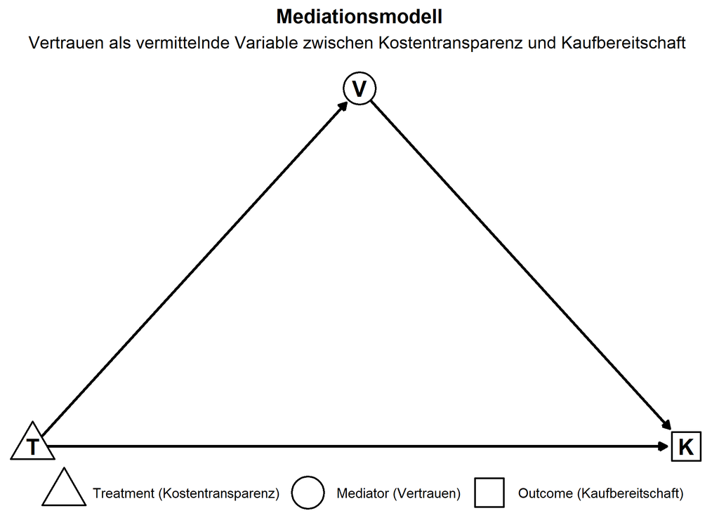

**Struktur und Aufbau des DAGs**

Der dargestellte Directed Acyclic Graph (DAG) bildet die vermutete kausale Struktur zwischen den drei zentralen Variablen dieser Studie ab: Treatment (T), Vertrauen (V) und Kaufbereitschaft (K).

Das Treatment besitzt in diesem DAG sowohl einen direkten als auch einen indirekten positiven kausalen Einfluss auf die Kaufbereitschaft. Der indirekte Einfluss ergibt sich daraus, dass das Treatment positiv auf das Vertrauen wirkt, welches wiederum zu einer höheren Kaufbereitschaft führt. Diese Struktur spiegelt die durch bisherige Analysen aufgestellte Hypothese des Vertrauens als vermittelnden psychologischen Mechanismus (Mediator) wider.

Es ist plausibel, dass Konsument:innen Unternehmen, die ihre Kostenstrukturen offenlegen, als transparenter und ehrlicher wahrnehmen, was ihr Vertrauen stärkt. Hat eine Person wiederum ein höheres Vertrauen in einen Anbieter, so ist es wahrscheinlicher, dass sie sich für den Kauf eines seiner Produkte entscheidet, insbesondere dann, wenn die möglichen Alternativen ähnlich sind. Letzterer Punkt wurde in der deskriptiven Analyse in Aufgabe 10 deutlich.

Neben diesem Wirkmechanismus ist es nicht auszuschließen, dass das Treatment auch einen weiteren Effekt auf die Kaufbereitschaft besitzt, der nicht über das Vertrauen verläuft. Beispielsweise könnte es sein, dass Konsument:innen Transparenz auch als ein moralisches Signal interpretieren, das unabhängig vom Vertrauensaufbau zu einer positiveren Bewertung des Unternehmens führt.

Da Konsumentenentscheidungen auf verschiedenen psychologischen Faktoren beruhen, ist es gut möglich, dass dieser zweite Effekt über andere Mediatoren verläuft, zum Beispiel über wahrgenommene Fairness, Verantwortungsbewusstsein oder Sympathie gegenüber der Marke.

Aus diesen Überlegungen ergibt sich die in diesem DAG dargestellte Kausalkette.

**Annahmen für die Interpretation von Vertrauen als Mediator**

Damit Vertrauen tatsächlich als Mediator interpretiert werden kann, müssen einige zentrale Annahmen erfüllt sein, welche im folgenden erläutert werden.

*1. Kausalität der Beziehungen:*

Es muss gelten, dass das Treatment kausal das Vertrauen beeinflusst und Vertrauen seinerseits kausal die Kaufbereitschaft erhöht. Nur wenn beide Zusammenhänge kausal sind, kann Vertrauen als vermittelnde Variable betrachtet werden.

*2. Keine unbeobachteten Confounder:*

Zwischen Treatment und Vertrauen sowie zwischen Vertrauen und Kaufbereitschaft dürfen keine unbeobachteten Confounder existieren, die beide Variablen beeinflussen. Andernfalls könnte der beobachtete Zusammenhang durch diese Störfaktoren verzerrt werden, indem der Effekt der Confounder fälschlicherweise als Effekt der Kostentransparenz auf Vertrauen bzw. als Effekt des Vertrauens auf die Kaufbereitschaft interpretiert wird.

*3. Kein umgekehrter Kausalfluss:* Darüber hinaus muss ausgeschlossen werden, dass Vertrauen seinerseits durch die Kaufbereitschaft beeinflusst wird. Eine solche Rückkopplung würde gegen die Grundannahmen eines DAG verstoßen, da zyklische Kausalbeziehungen in einem gerichteten, azyklischen Graphen nicht zulässig sind.

*3. Randomisierung des Treatments:*

Durch die zufällige Zuweisung zum Treatment (wie im Design von Experiment 2 vorgesehen) kann weitgehend ausgeschlossen werden, dass systematische Confounder den Zusammenhang zwischen Treatment und Vertrauen bzw. Kaufbereitschaft verzerren. Damit wird die Grundlage für eine kausale Interpretation gestärkt.

**Mögliche Verzerrungen und Störfaktoren**

Trotz einer theoretischen Klarheit könnten in der empirischen Umsetzung verschiedene Probleme auftreten, die den Mediator-Effekt des Vertrauens verzerren:

Zum einen könnte die Annahme der *unbeobachteten Confounder* verletzt sein.

Durch die Randomisierung des Treatments ist ein Confounder zwischen dem ersten Variablenpaar (Treatment und Vertrauen) unwahrscheinlich. Zwischen Vertrauen und Kaufbereitschaft könnten jedoch Persönlichkeitsmerkmale oder Markenerfahrungen als Confounder wirken. Aufgrund der Randomisierung ist jedoch zu erwarten, dass auch solche Merkmale über die Experimentalgruppen hinweg im Mittel gleich verteilt sind.

Ein Sonderfall tritt auf, wenn ein potenzieller Confounder nur in einer der beiden Gruppen relevant ist. Ein solches Beispiel könnte das Verständnis der Kostentransparenz-Information sein. In der Kontrollgruppe spielt dieses keine Rolle, da keine Informationen offengelegt werden. In der Treatment-Gruppe könnte jedoch ein mangelndes Verständnis zu einem niedrigeren Vertrauensniveau führen, da die wahrgenommene Transparenz geringer ist. Gleichzeitig könnten Personen mit geringerem Kostenverständnis aufgrund anderer Faktoren wie dem Markenimage eher geneigt sind, Everlane zu bevorzugen. In diesem Fall würde Verständnis als Confounder zwischen Vertrauen und Kaufbereitschaft wirken und wäre nicht durch die Randomisierung ausgeschlossen.

Auch wenn dieses Szenario denkbar ist, erscheint es empirisch eher unwahrscheinlich. Insgesamt ist deshalb mit hoher Wahrscheinlichkeit davon auszugehen, dass die Annahme der Confounderfreiheit zwischen dem Mediator und den anderen beiden Varaiablen in diesem Experiment weitgehend erfüllt ist.

Ein ähnlicher Fall, der zu Verzerrungen führen könnte ist ein *Post-treatment Bias*. Wenn Vertrauen nicht nur durch das Treatment, sondern auch durch weitere spätere Informationen beeinflusst wird, kann dies die Rolle von Vertrauen als reinem Mediator schwächen.

Ein weiterer möglicher Störfaktor wären *Messfehler*. Solche könnten bei der Erhebung der Trust-Skala zu einer Unterschätzung des Mediationseffekts führen.

Zuletzt könnte auch eine *Überlappung von Mediator und Outcome* könnte verzerrend wirken: Wenn Vertrauen und Kaufbereitschaft stark korrelieren (Rückkausalität), kann diese Multikollinearität führen die Stabilität der Schätzung in einer Regressionsanalyse beeinträchtigt.

**Fazit**

Der dargestellte DAG bietet ein visuelles Modell, das die theoretische Annahme stützt, dass Vertrauen ein kausaler Vermittler zwischen Kostentransparenz und Kaufbereitschaft ist. Um diese Hypothese empirisch zu prüfen, wäre eine tiefergehende Mediationsanalyse notwendig, bei der sowohl der direkte als auch der indirekte Effekt des Treatments geschätzt wird. Die Voraussetzung für eine saubere Interpretation ist jedoch, dass keine unbeobachteten Störvariablen vorliegen und die Randomisierung korrekt durchgeführt wurde. Wird dies erfüllt, erlaubt das Modell wertvolle Rückschlüsse auf psychologische Wirkmechanismen im Konsumentenverhalten.

15. Führen Sie nun eine Regression durch, bei der Ihnen `trust` (Vertrauen) als abhängige Variable dient. Weiterhin soll ihnen `treatment` als erklärende Variable dienen. Erstellen sie eine weitere Regression, die zusätzlich noch für die folgenden Variablen kontrolliert: Alter, Einkommensniveau, Bildungsstufe und ob die Personen weiblich sind.

Stellen Sie die Regressionsergebnisse in einer Tabelle mit stargazer oder modelsummary dar!

Beschreiben und interpretieren Sie ihre Ergebnisse. Gehen Sie bei der Interpretation der Ergebnisse insbesondere auf folgende Fragen ein:

- Macht es ihrer Ansicht nach Sinn auf die zusätzlichen Variablen in Regression 2 zu kontrollieren? Worauf müssen Sie besonders achten?
- Was bedeutet ein signifikanter positiver Koeffizient für treatment in Bezug auf Vertrauen?
- Warum ist dieser Pfad (Treatment ➝ Trust) notwendig, damit eine Mediation überhaupt möglich ist?
- Überlegen Sie, ob andere Faktoren, die Sie möglicherweise nicht berücksichtigt haben, diesen Zusammenhang ebenfalls erklären könnten.

Regressionsanalyse: Einfluss des Treatments auf Vertrauen

|  | Modell 1: Ohne Kontrolle | Modell 2: Mit Kontrolle |
| --- | --- | --- |
| Treatment (Kosteninfo) | 0.473*** | 0.454*** |
|  | (0.112) | (0.113) |
|  | (<0.001) | (<0.001) |
| Alter |  | -0.001 |
|  |  | (0.005) |
|  |  | (0.872) |
| Einkommen |  | -0.021 |
|  |  | (0.024) |
|  |  | (0.391) |
| Bildung |  | 0.058 |
|  |  | (0.067) |
|  |  | (0.388) |
| Weiblich |  | 0.179 |
|  |  | (0.114) |
|  |  | (0.118) |
| Num.Obs. | 601 | 601 |
| R2 | 0.029 | 0.035 |
| Log.Lik. | -1042.644 | -1040.795 |
| F | 17.791 | 4.291 |
| RMSE | 1.37 | 1.37 |

+ p < 0.1, * p < 0.05, ** p < 0.01, *** p < 0.001

**Beschreibung**

Zur Überprüfung der Annahme, dass die transparente Offenlegung von Produktionskosten (Treatment) das Vertrauen in das Unternehmen signifikant erhöht, wurden zwei lineare Regressionsmodelle geschätzt. Im ersten Modell dient das Treatment als einzige erklärende Variable. Das zweite Modell kontrolliert zusätzlich für Alter, Einkommen, Bildungsstand und Geschlecht (weiblich).

**Interpretation der Ergebnisse**

In beiden Modellen zeigt sich ein positiver und hoch signifikanter Effekt des Treatments auf das Vertrauen. Der Koeffizient beträgt rund 0,47 im Modell ohne Kontrolle und etwa 0,45 im Modell mit Kontrolle – jeweils auf dem 1 %-Niveau signifikant. Dies bedeutet, dass Personen, die die transparente Kosteninformation sahen, im Durchschnitt etwa 0,45–0,47 Punkte höheres Vertrauen äußerten (Skala 1–7).

Der Effekt bleibt auch unter Kontrolle relevanter Kovariablen nahezu unverändert. Das spricht für die Robustheit des Zusammenhangs und stützt die Annahme eines kausalen Effekts des Treatments.

**Sinnhaftigkeit der Kontrollvariablen**

Die Kontrolle für Alter, Einkommen, Bildung und Geschlecht kann aus zwei Gründen sinnvoll sein:

*Effizienzsteigerung:* Selbst bei erfolgreicher Randomisierung kann die Kontrolle zu geringerer Residualvarianz und damit zu präziseren Schätzungen führen.

*Robustheitsprüfung:* Ein stabiler Treatment-Koeffizient bei Hinzunahme von Kontrollen bestätigt die Unabhängigkeit vomografischer Verzerrungen.

Allerdings ist zu beachten, dass das Treatment randomisiert zugewiesen wurde. Wenn die Randomisierung korrekt umgesetzt wurde (vgl. Balancing-Tabelle in Aufgabe 8), sollten demografische Merkmale nicht systematisch mit der Treatment-Zuweisung korreliert sein. In diesem Fall ist Kontrolle zwar nicht notwendig für eine kausale Interpretation, aber methodisch unbedenklich – solange es sich nicht um Mediatoren oder Collider handelt.

Besonders wichtig ist daher die theoretisch informierte Modellierung. Wird z. B. fälschlich ein Mediator (wie Vertrauen) kontrolliert, kann dies den kausalen Pfad abschneiden und den Effekt unterschätzen. Eine unbeabsichtigte Kontrolle eines Colliders kann Scheinkorrelationen erzeugen.

**Bedeutung eines signifikanten Effekts von Treatment auf Vertrauen**

Der signifikante positive Effekt des Treatments ist eine notwendige Bedingung für Mediation: Nur wenn Vertrauen tatsächlich durch das Treatment beeinflusst wird, kann es als vermittelnder Mechanismus zwischen Kostentransparenz und Kaufbereitschaft wirken.

Der Befund legt somit nahe, dass das Treatment nicht nur unmittelbar, sondern auch über psychologische Kanäle – hier: Vertrauen – wirkt. Dies unterstützt die in Aufgabe 14 entwickelte Kausalstruktur und bestätigt den vermuteten Pfad: Treatment → Vertrauen → Kaufbereitschaft.

**Mögliche alternative Erklärungen**

Auch bei signifikanter Regressionsschätzung können andere, unbeobachtete Faktoren die Kausalinterpretation gefährden. Denkbar wären:

*Kognitive Fähigkeiten oder Vorwissen:* Personen mit besserem Kostenverständnis könnten das Treatment besser verarbeiten und zugleich generell mehr Vertrauen äußern.

*Soziale Erwünschtheit:* Teilnehmer könnten sich in der Treatment-Gruppe eher geneigt fühlen, positiv zu antworten.

*Markenerfahrung oder -sympathie:* Frühere Erfahrungen mit dem Unternehmen könnten Vertrauen beeinflussen, ohne vom Treatment verursacht zu sein.

Solche unbeobachteten Confounder können prinzipiell zu Verzerrungen führen. Aufgrund der Randomisierung und der guten Balancing-Ergebnisse erscheint dies im vorliegenden Fall jedoch weniger plausibel.

**Fazit**

Die Regressionsanalyse zeigt deutlich, dass die transparente Offenlegung von Kosteninformationen einen signifikanten und robusten Einfluss auf das Vertrauen in die Marke hat. Der Effekt bleibt auch bei Kontrolle für relevante demografische Variablen bestehen und ist statistisch wie theoretisch überzeugend.

Damit ist eine zentrale Voraussetzung für einen psychologischen Mediationsmechanismus erfüllt. Vertrauen kann im nächsten Schritt als potenzielle vermittelnde Variable betrachtet und im Rahmen einer Mediationsanalyse näher untersucht werden. Die Ergebnisse stützen somit die Hypothese, dass sich Kostentransparenz nicht nur direkt, sondern auch indirekt über Vertrauen positiv auf das Konsumentenverhalten auswirken kann.

16. Nachdem Sie nun den Effekt des Treatments auf das Vertrauen geschätzt und ausgewertet haben, sollen Sie nun testen, ob das Vertrauen als Mediator zwischen Treatment und Kaufabsicht wirkt.

Führen Sie eine Regression durch, bei der Ihnen die Kaufbereitschaft als abhängige Variable dient. Weiterhin sollen die erklärende Variablen nun `treatment`, sowie das Vertrauen (`trust`) umfassen. Erstellen sie eine weitere Regression, die zusätzlich noch auf Alter, Einkommensniveau, Bildungsstufe und ob die Personen weiblich sind, kontrolliert.

Stellen Sie die Regressionsergebnisse passend in einer Tabelle dar!

Beschreiben und interpretieren Sie ihre Ergebnisse. Gehen Sie bei der Interpretation der Ergebnisse insbesondere auf folgende Fragen ein:

- Was könnten Ihrer Ansicht nach Gründe sein, dass `treatment` jetzt nicht mehr signifkant ist? Woran könnt das im Detail liegen?
- Warum ist es wichtig, `trust` und `treatment` gemeinsam in einem Modell zu betrachten?
- Warum könnte `trust` eine “notwendige Bedingung” sein, damit Transparenz der Kostenstruktur zu höherer Kaufbereitschaft führt?

Regression: Einfluss von Treatment und Vertrauen auf Kaufbereitschaft

|  | Ohne Kontrolle | Mit Kontrolle |
| --- | --- | --- |
| Treatment (Kostentransparenz) | 0.148 | 0.129 |
|  | (0.140) | (0.140) |
| Vertrauen | 0.813*** | 0.818*** |
|  | (0.050) | (0.050) |
| Alter |  | -0.013* |
|  |  | (0.006) |
| Einkommen |  | 0.041 |
|  |  | (0.030) |
| Bildung |  | 0.055 |
|  |  | (0.082) |
| Weiblich |  | -0.148 |
|  |  | (0.140) |
| Num.Obs. | 601 | 601 |
| R2 | 0.317 | 0.327 |
| R2 Adj. | 0.315 | 0.320 |
| AIC | 2335.9 | 2335.7 |
| BIC | 2349.1 | 2366.5 |
| RMSE | 1.68 | 1.67 |
| Std.Errors | IID | IID |

+ p < 0.1, * p < 0.05, ** p < 0.01, *** p < 0.001

**Beschreibung**

Die Tabelle zeigt die Ergebnisse zweier linearer Regressionsmodelle mit der Kaufbereitschaft als abhängiger Variable. Beide Modelle untersuchen, inwiefern das Treatment (Kostentransparenz) sowie das Vertrauen in das Unternehmen (trust) die Kaufabsicht beeinflussen. Modell 1 berücksichtigt nur diese beiden erklärenden Variablen, Modell 2 erweitert das Modell zusätzlich um die Kontrollvariablen Alter, Einkommen, Bildung und Geschlecht.

**Ergebnisse und Interpretation**

In beiden Modellen zeigt Vertrauen einen starken und hochsignifikanten positiven Einfluss auf die Kaufbereitschaft. Der Regressionskoeffizient liegt bei etwa 0.81 (p < 0.001) und bleibt auch nach Einbezug der soziodemografischen Kontrollen stabil. Dies unterstreicht die zentrale Rolle von Vertrauen für Konsumentscheidungen: Je höher das Vertrauen in das Unternehmen, desto höher die Bereitschaft, ein Produkt zu kaufen.

Im Gegensatz dazu verliert der Effekt des Treatments seine Signifikanz, sobald Vertrauen im Modell enthalten ist. Der zuvor noch signifikante Effekt (vgl. Aufgabe 12) reduziert sich in beiden Spezifikationen auf etwa 0.13–0.15 und wird statistisch unbedeutend (p > 0.1). Dieses Muster legt nahe, dass das Treatment seinen Einfluss nicht direkt, sondern indirekt über das Vertrauen entfaltet – ein klassisches Merkmal für einen Mediationsmechanismus.

**Warum ist treatment nicht mehr signifikant?**

Dass der Treatment-Koeffizient nach Aufnahme von Vertrauen ins Modell nicht mehr signifikant ist, spricht für eine vollständige Mediation. Die Wirkung der transparenten Kostenstruktur wird vollständig durch das Vertrauen vermittelt: Treatment ➝ Vertrauen ➝ Kaufbereitschaft

Die Kostentransparenz erhöht das Vertrauen, welches wiederum die Kaufabsicht steigert. Ohne Vertrauen als vermittelnde Variable entfaltet das Treatment keinen signifikanten direkten Effekt mehr auf die Kaufbereitschaft.

**Warum ist ein gemeinsames Modell sinnvoll?**

Die gleichzeitige Berücksichtigung von treatment und trust im selben Modell ist entscheidend, um zwischen direkten und indirekten Effekten zu unterscheiden. Nur auf diese Weise lässt sich prüfen, ob Vertrauen als Mediator wirkt. Ein signifikanter Effekt von trust bei gleichzeitiger Entwertung des Effekts von treatment ist ein typisches Muster für Mediation.

**Warum ist der Pfad Treatment ➝ Vertrauen notwendig für Mediation?**

Für eine Mediation muss die unabhängige Variable (Treatment) kausal auf den Mediator (Vertrauen) wirken. Nur wenn diese Voraussetzung erfüllt ist, kann Vertrauen als Übertragungskanal zwischen Treatment und Kaufbereitschaft fungieren. Die Ergebnisse aus Aufgabe 15 bestätigen, dass das Treatment signifikant Vertrauen erhöht – somit ist diese Voraussetzung erfüllt.

**Könnten andere unbeobachtete Faktoren den Zusammenhang erklären?**

Auch wenn die Ergebnisse klar auf eine Mediation hindeuten, kann nicht vollständig ausgeschlossen werden, dass unbeobachtete Drittvariablen den Zusammenhang beeinflussen. Denkbar wären z. B.:

Kognitive Fähigkeiten oder finanzielle Bildung, die sowohl das Vertrauen als auch die Verarbeitung der Kosteninformation beeinflussen,

sozial erwünschtes Antwortverhalten oder

Markenpräferenzen aus früheren Erfahrungen.

Dank der Randomisierung im Experiment ist das Risiko solcher Confounder jedoch reduziert. Die Balancing-Tabelle (Aufgabe 8) zeigt keine systematischen Unterschiede zwischen den Gruppen, sodass eine verzerrte Zuordnung unwahrscheinlich ist.

**Fazit**

Die Analyse liefert klare Hinweise auf eine vollständige Mediation durch Vertrauen: Während Kostentransparenz allein nicht mehr signifikant zur Erklärung der Kaufabsicht beiträgt, entfaltet Vertrauen einen starken Effekt. Vertrauen ist somit kein bloßer Nebeneffekt von Transparenz, sondern eine notwendige Bedingung, damit Transparenz auf Konsumentenverhalten wirkt.

Die Ergebnisse betonen die strategische Relevanz vertrauensbildender Maßnahmen: Wer Konsumentenverhalten beeinflussen möchte, muss gezielt Vertrauen aufbauen – sei es durch Preisoffenlegung, Kommunikation oder soziale Signale.

In den vorangegangenen Modellen wurde untersucht, ob das Treatment (Kostentransparenz) das Vertrauen in das Unternehmen beeinflusst und ob Vertrauen wiederum mit der Kaufabsicht zusammenhängt.

17. Bewerten Sie das experimentelle Design der Studie 2. Gehen Sie dabei auch darauf ein, inwiefern Ihre Ergebnisse aus Aufgabe 13 bis 16 das theoretische Verständnis von Vertrauensbildung in der Konsumentenpsychologie bestätigt oder infrage stellt. Welche Stärken und Schwächen sehen Sie bezüglich der internen Validität und der Kausalitätsaussagen? Diskutieren Sie zudem kurz, inwiefern die Ergebnisse auf andere Bevölkerungsgruppen oder kulturelle Kontexte übertragbar sind.

*Hinweis:* Informationen zum Verständnis der Vertrauensbildung in der Konsumentenpsychologie können Sie [in dem folgenden Artikel](https://www.shs-conferences.org/articles/shsconf/pdf/2021/26/shsconf_appsconf2021_03019.pdf) auf Seite 2 bis 5 nachlesen.

**1. Theoretischer Hintergrund: Vertrauen als psychologischer Wirkmechanismus**

Vertrauen gilt in der Konsumentenpsychologie als ein zentraler Wirkmechanismus zur Reduktion von Unsicherheit in Entscheidungssituationen. Gerade bei asymmetrischer Informationsverteilung – etwa bei komplexen Produkten oder ethischen Fragen – ist Vertrauen eine kognitive und emotionale Brücke, die Handlungsfähigkeit überhaupt erst ermöglicht (vgl. Zsigmondová et al., 2021, S. 2–5).

Die Studie 2 prüft dieses theoretische Modell experimentell anhand der Frage, ob Kostentransparenz das Vertrauen erhöht – und ob dieses Vertrauen wiederum die Kaufbereitschaft steigert. Die Ergebnisse aus Aufgaben 13 bis 16 bestätigen diese Annahme:

Das Treatment (Kostentransparenz) erhöht das Vertrauen signifikant (Aufgabe 15),

Vertrauen hat einen starken Einfluss auf die Kaufbereitschaft (Aufgabe 16),

Der Effekt des Treatments verschwindet, sobald Vertrauen kontrolliert wird – ein klassisches Muster vollständiger Mediation.

Damit bestätigt die Studie ein zentrales Prinzip aus der Konsumentenpsychologie: Transparenz wirkt nicht direkt, sondern vermittelt über den Aufbau von Vertrauen, das wiederum die Handlung (Kaufabsicht) beeinflusst.

**2. Stärken des Designs: Hohe interne Validität und Kausalitätsaussagen**

Die Randomisierung der Teilnehmer auf die Experimentalbedingungen (Treatment vs. Kontrolle) ist die zentrale Stärke des Designs. Sie sorgt dafür, dass Unterschiede im Vertrauen oder der Kaufbereitschaft kausal auf das Treatment zurückgeführt werden können – vorausgesetzt, Störfaktoren sind zufällig verteilt.

Weitere methodische Stärken:

Glaubwürdige Manipulation: Die Offenlegung der Produktionskosten ist realitätsnah und gut operationalisiert.

Theoriegeleitete Mediationsanalyse: Die Analyse geht über einfache Effekte hinaus und untersucht mit hoher theoretischer Tiefe, wie das Treatment wirkt – nämlich über Vertrauen.

Die saubere Trennung zwischen direktem und indirektem Effekt erlaubt es, die psychologische Wirkungskette (Treatment → Vertrauen → Kaufverhalten) empirisch zu überprüfen.

**3. Limitationen: Risiken für interne und externe Validität**

*a) Interne Validität*

Messfehler bei Vertrauen: Eine unpräzise oder wenig valide Erfassung des Konstrukts „Vertrauen“ würde die Schätzung des Mediatorpfads verzerren.

Post-treatment Confounding: Wenn nach dem Treatment unbeobachtete Einflüsse Vertrauen oder Kaufverhalten beeinflussen (z. B. Markenimage, andere Informationen), könnte dies die Interpretation verzerren.

Soziale Erwünschtheit: Da Vertrauen und Kaufabsicht selbstberichtete Maße sind, besteht die Gefahr systematischer Verzerrungen, etwa durch ethische Selbstdarstellung.

*b) Externe Validität*

Stichprobenstruktur: Die Online-Stichprobe besteht vermutlich aus jungen, freiwilligen Teilnehmern mit überdurchschnittlicher Bildung. Die Ergebnisse lassen sich daher nur bedingt auf die Gesamtbevölkerung übertragen.

Kulturelle Einflüsse: Vertrauen und Transparenz werden in unterschiedlichen Kulturen verschieden interpretiert. Während in individualistischen Ländern wie Deutschland Transparenz stark vertrauensfördernd wirkt, könnten in kollektivistischeren Kontexten andere Faktoren (z. B. Markenbindung, soziale Zugehörigkeit) dominieren. Die kulturelle Generalisierbarkeit ist daher begrenzt (vgl. Zsigmondová et al., 2021).

**4. Fazit**

Das experimentelle Design der Studie 2 überzeugt durch:

eine hohe interne Validität,

klare kausale Identifikation der Wirkung von Kostentransparenz,

und eine fundierte Analyse des psychologischen Wirkmechanismus über Vertrauen.

Die Ergebnisse bestätigen zentrale Theorien der Konsumentenpsychologie: Vertrauen ist nicht nur ein gewünschter Nebeneffekt, sondern die zentrale Voraussetzung für die Wirksamkeit von Transparenzmaßnahmen.

Trotzdem bestehen Einschränkungen hinsichtlich der externen Validität – insbesondere durch Stichprobenbias und kulturelle Kontextfaktoren.

Um die Generalisierbarkeit zu erhöhen, sollten vergleichbare Experimente mit unterschiedlichen Zielgruppen (z. B. Alter, Bildung, Konsumstil) und in verschiedenen kulturellen Kontexten durchgeführt werden. Nur so lässt sich prüfen, ob Vertrauen auch unter anderen Voraussetzungen als zentraler Wirkmechanismus zwischen Transparenz und Verhalten wirkt.

# Zusatzaufgabe

Zu Beginn des Projektes hatten wir erwähnt, dass die Experimente, welche im Projekt durchgeführt wurden, auf Grund eines Missgeschicks in der Online-Darstellung von unterschiedlichen Produkten zustande kam. Hier wurden von einem privat geführten Online-Händler Geldbörsen in fünf Farbvarianten angeboten, wobei beabsichtigt war, allen Farben eine einheitliche Kostentransparenz-Infografik zuzuordnen. Aufgrund eines Versehens wurde die Infografik jedoch nur bei drei Farben implementiert. Dieses zufällige Ereignis führte zu einer klaren Trennung zwischen den Produkten mit dieser und ohne diese Infografik. Das dadurch entstandene natürliche Experiment sollen Sie sich in der Zusatzaufgabe näher anschauen.

18. Lesen Sie sich den nachfolgenden Text zum Aufbau des natürlichen Experiments innerhalb dieses Papers durch und beantworten anschließend nachfolgende Fragen:

On December 2, 2013, a privately held online retailer launched a holiday gift shop with a single email to its mailing list, promoting a leather wallet offered in five colors (burgundy, black, grey, bone, and tan) and priced at $115.00. Later, at the end of January, to boost post-holiday sales, the retailer decided to add a cost transparency infographic to the online product detail pages for each of the wallet’s five color combinations. The retailer’s intention was to use the same infographic for all wallets since they differed only in color.

However, due to an inadvertent mistake, the infographic was not introduced for two of the wallet colors (bone and tan). Consequently, the cost transparency information was implemented for only three of the five wallet colors (burgundy, black, and grey) over a period of five weeks. This error created a natural experiment, enabling us to test the impact of cost transparency on wallet sales.

Therefore we have the following procedure:

- Operationalization of Cost Transparency: The infographic presented the total cost to produce the wallet, breaking it down into its specific components, namely: leather (14.68 US-Dollar), construction (38.56 US-Dollar), duties (4.26 US-Dollar), and transportation (1.00 US-Dollar). In addition, it included benchmark information indicating that the wallet had a 1.9x markup, in contrast to a 6x markup charged by a competitor. Because wallet colors serve as the basis for treatment assignment, the natural experiment compares “cost transparent” wallets (burgundy, black, and grey) to “non-transparent” wallets (bone and tan).
- Identification Strategy: We use a difference-in-differences approach to compare the daily sales between the treatment (cost transparency) and control (no cost transparency) groups before versus after the introduction of the infographic. By doing so, the design isolates the causal effect of cost transparency on the daily count of wallets sold for each color.
- Control Variables: Given that the cost transparency treatment was implemented by wallet color, and with only five available colors, it was necessary to control for potential confounders. For instance, we include a proxy for time-varying color popularity - the number of page views each wallet color received - and a proxy for time-varying inventory levels.

Beantworten Sie nun die folgenden Fragen in Bezug auf den vorherigen Text:

- Wie ist das natürliche Experiment aufgebaut, und warum wird es als solches klassifiziert?
- Welche Rolle spielt das zufällige Versäumnis, die Infografik bei zwei der fünf Farbvarianten einzuführen, in der Experimentstruktur?
- Warum ist es notwendig, Variablen wie Seitenaufrufe und Lagerbestandsproxies in die Analyse einzubeziehen?
  - Welche potenziellen Verzerrungen könnten auftreten, wenn diese Kontrollvariablen nicht berücksichtigt werden?

**Wie ist das natürliche Experiment aufgebaut, und warum wird es als solches klassifiziert?**

Das natürliche Experiment entstand durch ein Versehen des Online-Händlers: Die Einführung einer Kostentransparenz-Infografik wurde nur bei drei von fünf Farbvarianten einer Geldbörse umgesetzt, obwohl alle Farben in Preis, Qualität und Kostenstruktur identisch waren. Diese zufällige Variation in Kostenoffenlegung erlaubt eine quasi-experimentelle Untersuchung, bei der bestimmte Produkte (drei Farben) als Treatmentgruppe (mit Infografik) und andere (zwei Farben) als Kontrollgruppe (ohne Infografik) bterachtet werden können.

Es handelt sich um ein natürliches Experiment, weil die Zuteilung zur Behandlungs- oder Kontrollgruppe nicht absichtlich durch Forschende, sondern durch ein reales, zufälliges Ereignis (der Fehler des Online-Händlers) erfolgt ist. Somit kann man hier – ähnlich wie in einem randomisierten Experiment – kausale Effekte der Kostentransparenz auf den Verkaufserfolg analysieren.

**Welche Rolle spielt das zufällige Versäumnis, die Infografik bei zwei der fünf Farbvarianten einzuführen, in der Experimentstruktur?**

Die Rolle des zufälligen Versäumnisses des Online-Händlers ist zentral für die Entstehung des natürlichen Experiments, da es den Behandlungsmechanismus darstellt, durch den eine Treatment-Gruppe und eine Kontrollgruppe entsteht.

Durch den Umstand, dass die Zuteilung zur Infografik-Gruppe zufällig, aufgrund eines Fehlers, erfolgte (nicht systematisch nach Produktqualität, Nachfrage oder Preis), ist auf natürliche Weise eine Randomisierung geschehen. Dies schafft die Grundlage für eine Difference-in-Differences (DiD)-Analyse, bei der die Veränderung der Verkaufszahlen vor und nach der Einführung der Infografik zwischen den beiden Gruppen verglichen wird.

**Warum ist es notwendig, Variablen wie Seitenaufrufe und Lagerbestandsproxies in die Analyse einzubeziehen?**

Da die Stichprobe mit fünf Geldbürsenfarben sehr klein ist, ist es wahrscheinlich, dass trotz natürlicher Randomisierung dennoch signifikante Unterschiede zwischen Treatment- und Kontrollgruppe bestehen, welche Verzerrungen in Anylsen verursachen könnten.

Diese beiden Variablen dienen somit zur Kontrolle, um verzerrende Einflüsse (Confounder) auszuschließen, die mit der Farbvariante (und damit der Gruppenzugehörigkeit) zusammenhängen könnten:

Seitenaufrufe pro Farbvariante spiegeln die zeitlich schwankende Popularität bestimmter Farben wider. Wenn etwa schwarze Geldbörsen häufiger gesucht werden als bone-farbene, könnte dies unabhängig von der Infografik zu mehr Verkäufen führen.

Lagerbestandsproxies kontrollieren für Verfügbarkeit: Wenn eine Farbe ausverkauft oder nur begrenzt verfügbar ist, beeinflusst das ebenfalls die Verkaufszahlen – unabhängig der Kostenoffenlegung.

**Welche potenziellen Verzerrungen könnten auftreten, wenn diese Kontrollvariablen nicht berücksichtigt werden?**

Ohne die Einbeziehung dieser Kontrollvariablen könnten für Confounder typische Scheinkorrelationen entstehen, welche unsere Schätzer verzerren:

Popularitätsverzerrung: Wenn z.B. Farben mit Infografik ohnehin beliebter waren, würde ein positiver Effekt auf die Verkaufszahlen fälschlich der Infografik zugeschrieben, obwohl die Nachfrage dafür auch ohne diese höher gewesen wäre.

Lagerverfügbarkeitsverzerrung: Wenn bestimmte Farben kaum noch auf Lager waren, wären ihre geringeren Verkaufszahlen nicht der fehlenden Infografik, sondern schlicht der mangelnden Verfügbarkeit geschuldet sein, was ohne Kontrolle in der Koeffizientenschätzung nicht berücksichtigt werden würde.

Diese Verzerrungen würden die interne Validität des Experiments gefährden und könnten zu fehlerhaften Schlussfolgerungen über den tatsächlichen Effekt der Kostentransparenz führen.

Zusammengefasst: Das zufällige Versäumnis erlaubt einen kausalen Vergleich zwischen Behandlungs- und Kontrollgruppe; Kontrollvariablen wie Seitenaufrufe und Lagerbestand sind nötig, um alternative Erklärungen für Verkaufsmuster auszuschließen und sicherzustellen den wahren Effekt möglichst Verzerrungsfrei zu schätzen.

19. Lesen Sie weiterhin das Kapitel [“Difference-in-Differences” in Huntington-Klein (2021)](https://theeffectbook.net/ch-DifferenceinDifference.html), speziell Kapitel 18.1 und 18.2 und beantworten Sie die folgenden Fragen dazu:

Kann eine Difference-in-Differences-Regression helfen, den kausalen Effekt der Kostentransparenz auf die Verkaufszahlen zu identifizieren?

Gehen Sie bei der Beantwortung dieser Frage insbesondere auf die nachfolgenden Punkte ein:

- Welche Art von Variation nutzt eine DiD-Regression in diesem Fall zur Identifikation des Effekts?
- Welche Voraussetzung(en) müssen erfüllt sein, damit DiD eine gültige Kausalschätzung liefert?
  - Was bedeutet die „Parallel Trends“-Annahme in diesem Kontext?
  - Warum reicht es nicht aus, nur zu vergleichen, wie sich die Verkaufszahlen nach der Einführung verändert haben?
- Basierend auf dem Kontext des Buchkapitels zu Difference-in-Differences (DiD) und den Informationen aus `Aufgabe 18`, formulieren Sie bitte die **Regressionsgleichung**, mit der der Effekt der Kostentransparenzmaßnahme mithilfe eines DiD-Ansatzes untersucht werden kann.
  - Definieren Sie dabei klar alle verwendeten Variablen.
  - Stellen Sie die Regressionsgleichung in mathematischer Form dar.
  - Beschreiben und erklären Sie das von Ihnen aufgestellte Modell.

**Kann eine Difference-in-Differences (DiD) Regression helfen, den kausalen Effekt der Kostentransparenz auf Verkaufszahlen zu identifizieren?**

Ja, eine Difference-in-Differences-Regression (DiD) kann grundsätzlich dabei helfen, den kausalen Effekt einer Maßnahme – hier der Einführung von Kostentransparenz – auf die Verkaufszahlen zu identifizieren. DiD ist besonders geeignet für natürliche Experimente oder politische Maßnahmen, die zu einem bestimmten Zeitpunkt in einer Teilgruppe eingeführt werden, während andere Gruppen unbehandelt bleiben. Die zentrale Stärke von DiD liegt darin, Zeittrends und unbeobachtete, zeitinvariante Unterschiede zwischen Gruppen zu kontrollieren – vorausgesetzt, bestimmte Bedingungen sind erfüllt.

**Welche Art von Variation nutzt eine DiD-Regression in diesem Fall zur Identifikation des Effekts?**

DiD nutzt zwei Quellen der Variation:

Zeitliche Variation innerhalb der Gruppen (Before vs. After) Es wird untersucht, wie sich die Verkaufszahlen innerhalb der Treatmentgruppe und der Kontrollgruppe über die Zeit verändern.

**Gruppenunterschiede (Treated vs. Control)**

Zusätzlich wird betrachtet, wie sich diese Veränderungen zwischen Gruppen unterscheiden – also ob sich die Verkaufszahlen in der Gruppe mit Kostentransparenz anders entwickeln als in der Gruppe ohne.

Die Grundidee ist: Wenn sich Verkaufszahlen in der Kontrollgruppe nur geringfügig verändern, aber in der Treatmentgruppe stark ansteigen, kann der Unterschied auf die Maßnahme zurückgeführt werden – unter bestimmten Annahmen.

**Welche Voraussetzung(en) müssen erfüllt sein, damit DiD eine gültige Kausalschätzung liefert?**

Die zentrale Voraussetzung: Parallel-Trends-Annahme Die wichtigste Bedingung ist die sogenannte Parallel-Trends-Annahme. Sie besagt:

Ohne das Treatment hätten sich die Verkaufszahlen in der Behandlungs- und der Kontrollgruppe im gleichen Maße verändert.

Das bedeutet nicht, dass beide Gruppen identische Verkaufszahlen haben müssen – wohl aber, dass ihre Entwicklungen (Trends) ohne Intervention parallel verlaufen wären. Nur dann können wir eine Veränderung in der Differenz tatsächlich als Effekt des Treatments interpretieren.

Warum reicht es nicht aus, nur zu vergleichen, wie sich die Verkaufszahlen nach der Einführung verändert haben? Ein Vorher-Nachher-Vergleich innerhalb der Treatmentgruppe reicht nicht, weil sich Verkaufszahlen auch ohne Intervention verändern können – etwa durch saisonale Effekte, Preisschwankungen, neue Konkurrenz oder gesamtwirtschaftliche Trends.

*Beispiel:*

Wenn die Verkaufszahlen nach Einführung der Kostentransparenz steigen, kann das nicht eindeutig auf die Maßnahme zurückgeführt werden. Vielleicht wäre der Anstieg auch ohne Kostentransparenz passiert. Die Kontrollgruppe liefert hier ein Gegenfaktum, indem sie zeigt, wie sich die Verkaufszahlen ohne Maßnahme entwickelt hätten.

**Wie sieht die Regressionsgleichung im DiD-Ansatz aus?**

*Wir definieren folgende Variablen:*

Variable Bedeutung Yit: Verkaufszahlen der Person oder Gruppe i zum Zeitpunkt t

Treat i: Dummy: 1 = gehört zur Treatmentgruppe, 0 = Kontrollgruppe

Post t: Dummy: 1 = Zeitraum nach Einführung der Maßnahme, 0 = davor

Treat i × Post t: Interaktion: 1 = Einheit ist behandelt und im Nach-Zeitraum

Die DiD-Regressionsgleichung lautet:

Yit = ß0 + ß1 * Treat i + ß2 * Post t + ß3 * (Treati x Postt) + ϵit

*Bedeutung der Koeffizienten:*

β0: Verkaufszahlen der Kontrollgruppe im Vorher-Zeitraum

β1: Unterschied zwischen Treatment- und Kontrollgruppe vor der Intervention

β2: Zeitlicher Effekt (z.B. Markttrends), der beide Gruppen betrifft

β3: Kausaler Effekt der Kostentransparenz (DiD-Schätzer)

Wenn die Parallel-Trends-Annahme gilt, ist β3 eine unverzerrte Schätzung des durchschnittlichen Behandlungs-Effekts („Average Treatment Effect on the Treated“).

**Wie lässt sich dieses Modell im Kontext der Aufgabe interpretieren?**

Stellen wir uns vor, eine Gruppe von Konsumenten erhält ein Produktangebot mit vollständiger Kostenaufstellung (Treatment), während eine andere Gruppe ein identisches Produktangebot ohne transparente Darstellung der Zusatzkosten erhält (Kontrolle).

Vor der Einführung gibt es vielleicht kaum Unterschiede zwischen den Gruppen.

Nach der Einführung der Kostentransparenz steigt die Verkaufsbereitschaft in der Treatmentgruppe – aber nicht in der Kontrollgruppe.

Dann kann die DiD-Schätzung zeigen, dass der zusätzliche Anstieg durch die Maßnahme selbst verursacht wurde, und nicht durch allgemeine externe Effekte.

**Fazit**

Die Difference-in-Differences-Regression ist ein leistungsstarkes Werkzeug zur Kausalanalyse, wenn man mit quasi-experimentellen Settings arbeitet. Im Kontext der Kostentransparenzmaßnahme ist sie besonders geeignet, um den kausalen Effekt auf Verkaufszahlen zu identifizieren – vorausgesetzt, die Parallel-Trends-Annahme ist plausibel.

Sie kontrolliert sowohl für zeitinvariante Unterschiede zwischen Gruppen als auch für gemeinsame Zeittrends, und liefert so eine robustere Aussage über die tatsächliche Wirkung einer Intervention als einfache Vorher-Nachher-Vergleiche.

20. Zum Abschluss des Projekts sollen Sie sich das oben beschriebene natürliche Experiment genauer anschauen. Lesen Sie hierzu die Daten (`Experiment3.csv`) in R ein. Nennen Sie den Datensatz `daten_exp3`. Erstellen Sie eine Variable `log_units`, die die logarithmierte Anzahl an verkauften Einheiten darstellt.

Erstellen Sie weiterhin eine passende Grafik, die die durchschnittliche Anzahl der verkauften Produkte je Treatment pro Woche abbildet. Fügen Sie weiterhin eine vertikale Linie für den 28. Januar 2014 in ihre Grafik ein, welche die Einführung der Kostentransparenz markiert.

Beschreiben und interpretieren Sie ihre Grafik. Gehen Sie insbesondere auf die Entwicklung der durchschnittlichen Verkaufszahlen in beiden Gruppen vor und nach dem 28. Januar ein. Gibt es visuelle Hinweise auf eine Wirkung der Kostentransparenz?

- Angenommen, beide Gruppen (Treatment und Kontrolle) zeigen vor der Einführung der Kostentransparenz einen gleich starken Anstieg der durchschnittlich verkauften Einheiten. Was würde das für die Interpretation der Maßnahme im Rahmen eines Difference-in-Differences-Ansatzes bedeuten?

*Hinweis:* Für die Ableitung der Wochen aus dem Datumsformat kann die Funktion `isoweek()` aus dem Paket `lubridate` verwendet werden.

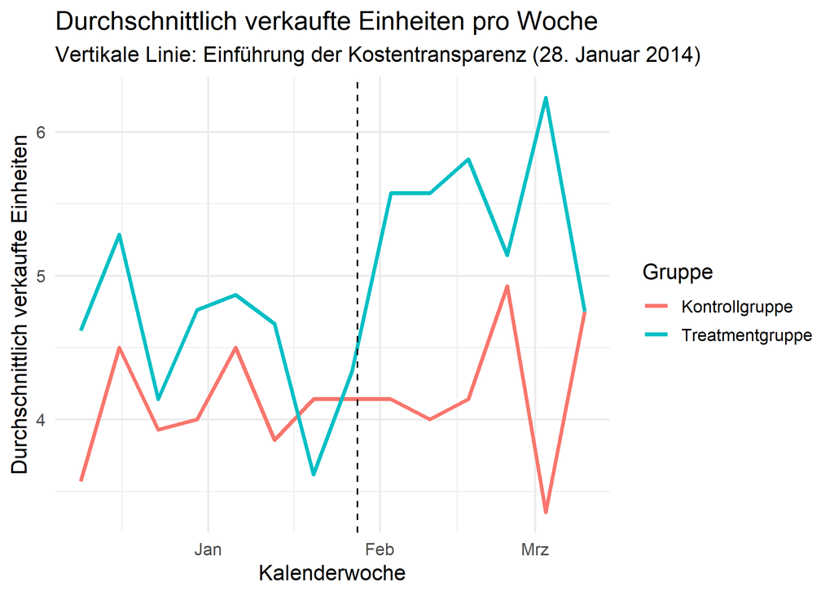

**Ziel der Aufgabe**

In dieser Aufgabe wurde untersucht, ob die Einführung einer Kostentransparenzmaßnahme am 28. Januar 2014 einen Einfluss auf die Verkaufszahlen hatte. Dazu wurden Daten eines natürlichen Experiments ausgewertet, bei dem eine Behandlungsgruppe (Treatmentgruppe) mit transparenter Kostenstruktur und eine Kontrollgruppe ohne solche Information existiert.

**Vorbereitung der Daten**

Zunächst wurden die Daten aus der Datei Experiment3.csv eingelesen und unter dem Namen daten_exp3 abgespeichert. Eine neue Variable log_units wurde erstellt, die den natürlichen Logarithmus der verkauften Einheiten pro Tag enthält. Dies dient dazu, Ausreißer und starke Schwankungen zu glätten und die Verteilung der Verkaufszahlen zu normalisieren.

Anschließend wurden die Daten mit Hilfe des Datums in Kalenderwochen gruppiert. Für jede Woche und Gruppe (Treatment vs. Kontrolle) wurde der durchschnittliche Absatz berechnet. Die Gruppierung ermöglichte eine aussagekräftige Zeitreihenanalyse, da Tagesdaten in diesem Kontext zu unruhig und schwer interpretierbar wären.

**Erstellung der Grafik**

Die resultierende Zeitreihe wurde grafisch dargestellt. Auf der X-Achse befindet sich der Verlauf der Kalenderwochen (ab Dezember 2013), auf der Y-Achse die durchschnittlich verkauften Einheiten pro Woche. Die Linien unterscheiden zwischen der Kontroll- und der Treatmentgruppe. Eine vertikale Linie am 28. Januar 2014 markiert den Zeitpunkt der Einführung der Kostentransparenz.

**Interpretation der Ergebnisse**

Nach der Maßnahme Nach dem 28. Januar zeigt sich ein klarer Effekt: Die Verkaufszahlen in der Treatmentgruppe steigen deutlich an, während die Kontrollgruppe in einem deutlich flacheren Verlauf verbleibt. Der Unterschied zwischen beiden Gruppen wird in den Wochen nach der Maßnahme sichtbar größer. Diese Entwicklung deutet darauf hin, dass die Einführung der Kostentransparenz einen positiven Effekt auf die Verkaufszahlen in der Treatmentgruppe hatte.

**Bedeutung im Kontext von Difference-in-Differences**

Die visuelle Analyse zeigt, dass die Parallel-Trends-Annahme vor dem Treatment plausibel erscheint. Wenn diese Voraussetzung gegeben ist, kann man mit dem Difference-in-Differences-Ansatz valide den kausalen Effekt der Maßnahme auf die Verkaufszahlen schätzen.

**Fazit**

Die grafische Auswertung liefert erste überzeugende Hinweise darauf, dass die Einführung von Kostentransparenz zu einem Anstieg der Verkaufszahlen geführt hat. Vor der Maßnahme waren die Gruppen vergleichbar, danach steigt der Absatz der Treatmentgruppe deutlich stärker. Die Voraussetzung für eine Difference-in-Differences-Analyse scheint erfüllt, sodass eine weiterführende ökonometrische Schätzung des Maßnahmeneffekts gut begründet wäre.

Wenn gewünscht, kann im nächsten Schritt eine formale DiD-Regression durchgeführt werden, um die Wirkung statistisch abzusichern und die Größe des Effekts zu quantifizieren.

21. Erstellen Sie eine (mehrere) weitere passende Grafik(en), die die durchschnittlich verkauften Einheiten pro Tag in Treatment und Kontrolle vor und nach der Einführung der Kostentransparenz abbildet. Ergänzen Sie in ihrer Grafik die jeweiligen Standardfehler als Fehlerbalken. Beschreiben und interpretieren Sie ihre Grafik. Gehen Sie insbesondere auf die Unterschiede vor und nach der Einführung der Kostentransparenz ein.
- Inwiefern lassen sich daraus erste Hinweise auf einen möglichen Effekt des natürlichen Experiments erkennen?

*Hinweis:* Für die Erstellung der Grafik können Sie sich an Aufgabe 7 und 9 orientieren.

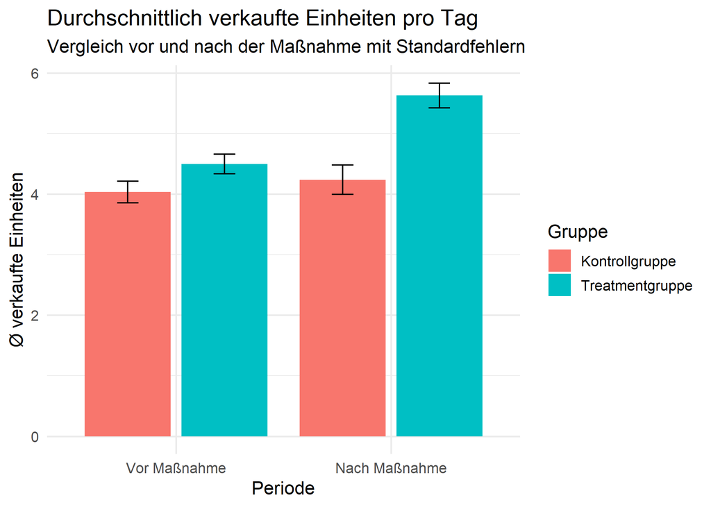

**Grafikbeschreibung und Interpretation**

Die dargestellte Balkengrafik zeigt die durchschnittlich verkauften Einheiten pro Tag, jeweils getrennt nach Gruppe (Kontroll- vs. Treatmentgruppe) und Zeitperiode (vor vs. nach Einführung der Kostentransparenz am 28. Januar 2014). Die vertikalen Fehlerbalken geben die jeweiligen Standardfehler des Mittelwerts an und ermöglichen eine Einschätzung der statistischen Unsicherheit.

Nach der Einführung der Kostentransparenz zeigt sich ein deutliches Bild:

Die Kontrollgruppe bleibt auf einem ähnlichen Niveau wie zuvor (~4,2 Einheiten).

Die Treatmentgruppe hingegen verzeichnet einen signifikanten Anstieg auf etwa 5,7 verkaufte Einheiten pro Tag.

Dieser Anstieg ist nicht nur absolut betrachtet groß, sondern übersteigt auch deutlich die obere Grenze des Standardfehlers der Kontrollgruppe – ein klares visuelles Signal für einen potenziellen kausalen Effekt.

**Hinweise auf einen möglichen Effekt des natürlichen Experiments**

Die Grafik liefert erste starke Hinweise auf einen positiven Effekt der Kostentransparenz:

Zeitliche Koinzidenz: Der Anstieg tritt direkt nach der Maßnahme auf – ein Hinweis auf eine mögliche Verursachung.

Nur in der Treatmentgruppe: Der Effekt ist nicht in der Kontrollgruppe zu beobachten, was gegen allgemeine Trends oder externe Schocks spricht.

Diese Beobachtungen sind konsistent mit einem Difference-in-Differences-Design, bei dem angenommen wird, dass sich beide Gruppen ohne Intervention parallel entwickelt hätten. Die beobachtete Differenz nach der Maßnahme kann daher als Effektschätzung interpretiert werden.

**Fazit**

22. In der vorherigen Aufgabe haben Sie den Effekt von Kostentransparenz auf die Verkaufszahlen anhand eines deskriptiven Vergleichs untersucht. Dabei haben Sie die durchschnittlich täglich verkauften Einheiten je Treatment vor und nach der Einführung der Transparenzmaßnahme grafisch gegenübergestellt. In dieser Aufgabe sollen Sie diesen Effekt nun ökonometrisch genauer untersuchen, indem Sie den Difference-in-Differences Ansatz in einem Regressionsrahmen anwenden.

Untersuchen Sie den Effekt der Einführung von Kostentransparenz auf die Verkaufszahlen mithilfe einer Difference-in-Differences Regression. Verwenden Sie hierfür Beobachtungen an Werktagen, sowie am Wochenende (Montag bis Sonntag), mit positiven Verkaufszahlen.

Erstellen Sie insgesamt zwei Regressionsmodelle:

- Basismodell ohne Kontrollvariablen
- Modell mit Kontrolle für Wochentagseffekte

Stellen Sie die Ergebnisse anschaulich dar. Beschreiben und interpretieren Sie Ihre Ergebnisse. Gehen Sie insbesondere auf folgende Aspekte ein.

- Wie würden Sie die Größe des Effekts interpretieren, den Sie für `treated:post` erhalten haben?
- Welche Vorteile bringt es, log_units (logarithmierte Verkäufe) als abhängige Variable zu verwenden?
- Können Sie aus Ihrer Schätzung auf einen kausalen Effekt der Kostentransparenz schließen?
- Inwiefern hilft die Kontrolle für Wochentage dabei, Verzerrungen in der Schätzung zu vermeiden?
- Würden Sie auf Basis Ihrer Analyse eine Empfehlung zur Beibehaltung oder Ausweitung der Kostentransparenz geben?
- Worin könnten ihrer Ansicht nach Probleme liegen bei der Betrachtung eines natürlichen Experiments, die die Ergebnisse verzerren könnten?

*Hinweis 1:* Nutzen Sie für die Schätzung die `feols()`-Funktion aus dem fixest-Paket.

*Hinweis 2:* Nutzen Sie die logarithmierten täglichen Verkaufszahlen als abhängige Variable.

```
##                      Basismodell Mit Wochentag..
## Dependent Var.:   log(Verkäufe)  log(Verkäufe)
##
## Constant         1.28*** (0.049) 1.29*** (0.075)
## treated           0.105. (0.063)  0.106. (0.063)
## post               0.066 (0.077)   0.064 (0.077)
## Treatment × Post  0.182. (0.100)  0.182. (0.099)
## ________________ _______________ _______________
## S.E. type                    IID             IID
## Observations                 470             470
## R2                       0.06037         0.08098
## Adj. R2                  0.05432         0.06300
## ---
## Signif. codes: 0 '***' 0.001 '**' 0.01 '*' 0.05 '.' 0.1 ' ' 1
```

**Einleitung**

In den vorangegangenen Aufgaben wurden die Effekte der Einführung von Kostentransparenz bereits deskriptiv untersucht. Eine visuelle Auswertung deutete darauf hin, dass sich nach der Maßnahme die Verkaufszahlen in der Treatmentgruppe signifikant erhöhten, während die Kontrollgruppe stabil blieb. In Aufgabe 22 soll nun dieser Effekt formal mithilfe eines ökonometrischen Modells im Rahmen eines Difference-in-Differences (DiD)-Ansatzes geschätzt werden. Ziel ist es, eine kausale Aussage darüber treffen zu können, ob die Transparenzmaßnahme tatsächlich eine nachweisbare Wirkung auf die Verkaufszahlen hatte.

**Methodisches Vorgehen und Modellierung**

Für die Analyse wurden die Daten aus der Datei Experiment3.csv verwendet und mit R aufbereitet. Zunächst wurden alle Beobachtungen herausgefiltert, bei denen die verkauften Einheiten null oder kleiner waren. Anschließend wurde eine logarithmierte Zielvariable (log_units) erstellt, um die Modellannahmen besser zu erfüllen, insbesondere die Normalverteilung der Fehler und Homoskedastizität. Außerdem wurden eine post-Variable zur Kennzeichnung des Zeitpunkts nach der Maßnahme (ab dem 28. Januar 2014) sowie eine Interaktion (treated × post) erstellt, welche den zentralen DiD-Term darstellt. Zusätzlich wurden die Wochentage aus dem Datumsformat extrahiert, um in einem erweiterten Modell Wochentagseffekte kontrollieren zu können.

Anschließend wurden zwei Regressionsmodelle mithilfe der feols()-Funktion aus dem Paket fixest geschätzt: Ein Basismodell ohne weitere Kontrollvariablen und ein erweitertes Modell, das zusätzlich Wochentagseffekte berücksichtigt. Beide Modelle verwenden die logarithmierten Verkaufszahlen (log_units) als abhängige Variable.

**Vorteile der logarithmierten Zielvariable**

Die Verwendung von log_units als abhängige Variable bringt mehrere Vorteile mit sich. Erstens lassen sich die Ergebnisse intuitiv als prozentuale Effekte interpretieren, was die wirtschaftliche Bedeutung erleichtert. Zweitens wird durch die Logarithmierung die Verteilung der abhängigen Variable symmetrischer und näher an die Normalverteilung gebracht, was die Voraussetzungen der linearen Regression besser erfüllt. Drittens reduziert sie die Einflussstärke extremer Ausreißer, was bei täglichen Verkaufszahlen besonders wichtig sein kann.

**Kausale Interpretation und Bedeutung der Parallel-Trends-Annahme**

Grundsätzlich erlaubt der Difference-in-Differences-Ansatz unter bestimmten Bedingungen eine kausale Interpretation. Eine zentrale Voraussetzung ist die sogenannte Parallel-Trends-Annahme. Sie besagt, dass sich die Verkaufszahlen in Treatment- und Kontrollgruppe ohne die Intervention in vergleichbarer Weise weiterentwickelt hätten. Diese Annahme erscheint in diesem Fall plausibel, da vor der Maßnahme in den vorangegangenen Aufgaben kein systematischer Unterschied im Trendverlauf beobachtet werden konnte.

**Kontrolle für Wochentagseffekte**

Die erweiterte Modellierung berücksichtigt explizit auch Wochentagseffekte, was einen wichtigen Beitrag zur Validität der Schätzung leistet. Verkaufszahlen unterliegen typischerweise einem regelmäßigen Wochenmuster: An bestimmten Tagen (z. B. Samstagen) werden häufig mehr Produkte verkauft als an anderen (z. B. Montagen). Wenn die Maßnahme zeitlich zufällig mehr auf verkaufsstarke oder -schwache Tage fällt, kann das die Schätzung verzerren. Durch die Kontrolle dieser Effekte wird eine systematische Verzerrung des DiD-Schätzers vermieden, wodurch die Ergebnisse deutlich robuster werden.

**Mögliche Verzerrungsquellen und Grenzen des natürlichen Experiments**

# Literatur

Mohan, B., Buell, R. W., & John, L. K. (2020). Lifting the veil: The benefits of cost transparency. Marketing Science, 39(6), 1105-1121. https://doi.org/10.1287/mksc.2019.1200

# Anhang

## Mediator

Im Rahmen von Mediationen ist der Mediator eine Variable, die den erklärenden Zusammenhang zwischen einer unabhängigen und einer abhängigen Variable vermittelt. Dabei wird untersucht, inwieweit der Einfluss der unabhängigen Variablen (z.B. Kostentransparenz) auf die abhängige Variable (z.B. Kaufabsicht) über einen vermittelnden Mechanismus - wie das Vertrauen der Kunden - erfolgt.

1. **Mediatoreffekt**: Der Mediatoren-Effekt, oft als ACME (Average Causal Mediation Effect) bezeichnet, beschreibt den indirekten Effekt, den die unabhängige Variable auf die abhängige Variable über den Mediator ausübt. Ist dieser Effekt signifikant, signalisiert dies, dass ein wesentlicher Teil des gesamten Einflusses über den vermittelnden Mechanismus läuft. Gleichzeitig kann ein nicht-signifikanter direkter Effekt (ADE - Average Direct Effect) darauf hindeuten, dass der Mediator den hauptsächlichen Erklärungsmechanismus darstellt.
2. **Funktion und Wirkung des Mediators**: Analog zum Konzept der signalgebenden Funktion bei Statussymbolen - deren Wert unter anderem von der Exklusivität und dem sozialen Kontext abhängt - fungiert der Mediator als vermittelnder Kanal, der erklärt, wie und warum der ursprüngliche Zusammenhang zwischen zwei Variablen zustande kommt. Der Mediator „überträgt“ quasi den Effekt der unabhängigen Variable auf die abhängige Variable. Dadurch kann in Modellen, in denen der direkte Zusammenhang zwischen der unabhängigen und der abhängigen Variable durch die Einbeziehung des Mediators verschwindet oder abgeschwächt wird, abgeleitet werden, dass der Mechanismus über den Mediator läuft. Dies ermöglicht ein tieferes Verständnis der zugrundeliegenden psychologischen Prozesse - etwa wie das Vertrauen der Kunden die Wirkung von Kostentransparenz auf deren Kaufabsicht vermittelt.

Zusammengefasst spielt der Mediator eine zentrale Rolle bei der Aufklärung der kausalen Mechanismen, indem er als vermittelnder Faktor zwischen Ursache und Wirkung identifiziert wird. Die signifikante Vermittlung über den Mediator zeigt, dass nicht allein das Vorhandensein von Kostentransparenz entscheidend ist, sondern auch, inwiefern diese Transparenz das Vertrauen stärkt - was wiederum maßgeblich die Kaufabsicht beeinflusst. So liefert die Mediationsanalyse wertvolle Einsichten, die über einfache bivariate Zusammenhänge hinausgehen und die Komplexität kausaler Mechanismen innerhalb von sozialen oder marktorientierten Prozessen sichtbar machen.